# Backpropagation Through Time - Giải Thuật Lan Truyền Ngược Theo Thời Gian

## Mục lục:

- I. Giới thiệu Recurrent Neural Network (RNN) và sự cần thiết của thuật toán Backpropagation through time (BPTT)
  - 1. Neural Network
    - 1.1. Giới thiệu
    - 1.2. Hạn chế của Neural Network truyền thống với dữ liệu tuần tự theo thời gian
  - 2. Recurrent Neural Network (RNN)
    - 2.1. Dữ liệu tuần tự theo thời gian
    - 2.2. Tổng quan về Recurrent Neural Network (RNN)
  - 3. Vấn đề Backpropagation trong Recurrent Neural Network
    - 3.1 Thuật toán Backpropagation hoạt động không tốt trên Recurrent Neural Network
    - 3.2 Sự cần thiết của Backpropagation Through Time (BPTT)
- II. Nền tảng Toán học của Lan truyền ngược qua thời gian
  - 1. Nền tảng Toán học
  - 2. Lan truyền ngược qua thời gian (Backpropagation Through Time - BPTT
- III. Full Computation - Backpropagation Through Time
  - 1. Giới thiệu Full Computation trong BPTT
  - 2. Thực thi Full computation trong BPTT
  - 3. Trực quan hóa Full computation trong BPTT
  - 4. Minh họa kết quả Full Computation trong BPTT
  - 5. Những thách thức của tính toán đầy đủ
  - 6. Minh họa lưu trữ trong bộ nhớ
  - 7. Kết luận
- IV. Giải pháp và Các phương pháp huấn luyện khác
  - 1. Giải pháp xử lý vanishing/exploding gradients bằng Truncated BPTT
    - 1.1. Nguyên lý hoạt động
    - 1.2. Ưu điểm của phương pháp trên
    - 1.3. Ứng dụng thực tế
    - 1.4. Hạn chế
    - 1.5. Hiện thực
  - 2. Giải pháp xử lý vanishing/exploding gradients bằng Truncated BPTT: Randomized Truncation
    - 2.1. Nguyên lý hoạt động
    - 2.2. Ưu điểm của Randomized Truncation
    - 2.3. Hạn chế của Randomized Truncation
    - 2.4. Ví dụ bài toán: Dự đoán giá trị trong chuỗi thời gian
    - 2.5. Kế hoạch triển khai
- V. Ứng dụng BPTT
  - 1. Ứng dụng BPTT trong Language Modeling
    - 1.1. Bài toán Language Modeling là gì?
    - 1.2. Vì sao cần sử dụng RNN và BPTT?
    - 1.3. Vai trò của BPTT trong huấn luyện Language Model
  - 2. Ứng dụng BPTT trong Machine Translation
    - 2.1. Mô hình dịch máy là gì?
    - 2.2. Tại sao cần BPTT trong Machine Translation?
  - 3. Ứng dụng BPTT trong Dự báo chuỗi thời gian (Time Series Forecasting)
    - 3.1. Time Series là gì? Time Series Forecasting là gì?
    - 3.2. Tại sao cần BPTT trong Time Series Forecasting?
    - 3.3. Ứng dụng BPTT trong Dự báo chuỗi thời gian: Demo dự báo giá cổ phiếu
  - 4. Ứng dụng BPTT trong Học tăng cường: Học từ các tín hiệu phần thưởng tuần tự
    - 4.1. Bài toán học tăng cường (Reinforcement Learning)
    - 4.2. Vai trò của BPTT trong RL
    - 4.3. Minh họa trực quan
- VI. Gỉải bài tập
  - 1. Bài tập 1
    - 1.1. Bài tập 1a
    - 1.2. Bài tập 1b
    - 1.3. Bài tập 1c
  - 2. Bài tập 2
- Tài liệu tham khảo

# I. Giới thiệu Recurrent Neural Network (RNN) và sự cần thiết của thuật toán Backpropagation through time (BPTT)

# 1. Neural Network

## 1.1. Giới thiệu

Neural Network là một mô hình học máy mô phỏng hoạt động tương tự hệ thần kinh của con người. Neural Network bao gồm các lớp neuron liên kết với nhau bằng các trọng số, với cơ chế hoạt động:

- Nhận đầu vào (input).
- Tính toán tổng có trọng số + bias.
- Áp dụng hàm kích hoạt (activation function).
- Xuất ra giá trị dự đoán (output).

Trong quá trình huấn luyện, thuật toán **Backpropagation** được sử dụng để cập nhật trọng số của mạng, sao cho đầu ra tiệm cận giá trị mong muốn.

Ví dụ mô hình đơn giản:

- Input → Hidden Layer → Output Layer

[figure not shown]

Mô hình Neural Network đơn giản

Nguồn: [Cloudflare. What is a Neural Network?](https://www.cloudflare.com/learning/ai/what-is-neural-network/)

## 1.2. Hạn chế của Neural Network truyền thống với dữ liệu tuần tự theo thời gian

Neural Network truyền thống chỉ có thể xử lý thông tin theo một chiều từ Input → Output. Công thức chung: $$ \mathbf{h}^{(l)} = \sigma(\mathbf{W}^{(l)} \mathbf{h}^{(l-1)} + \mathbf{b}^{(l)}) $$

Trong đó:

- $\mathbf{h}^{(l)}$ là vector output tầng $l$.
- $\mathbf{W}^{(l)}$, $\mathbf{b}^{(l)}$ là ma trận trọng số và bias.
- $\sigma$ là hàm kích hoạt (ReLU, tanh, sigmoid...).

Chính vì thông tin chỉ đi được một chiều mà không thể quay lại (do không có vòng lặp), các input tại các node không thể nhớ thông tin nào từ trước. Bên cạnh đó, nếu xử lý nhiều input, thì các input này cũng được xử lý độc lập và không biết giá trị trước sau. Cụ thể:

- Giả sử với chuỗi input: $$ \mathbf{x}_1, \mathbf{x}_2, \mathbf{x}_3, \ldots, \mathbf{x}_T $$
- Với Neural Network truyền thống: $$ \mathbf{y}_t = f(\mathbf{x}_t) $$
- Nhưng thực tế cần xử lý tuần tự: $$ \mathbf{y}_t = f(\mathbf{x}_1, \mathbf{x}_2, \ldots, \mathbf{x}_t) $$

Trong thực tế, rất nhiều bài toán trong thực tế đòi hỏi mô hình phải "nhớ" được các dữ liệu trong quá khứ, liên kết chúng lại và dự đoán giá trị output. Chẳng hạn như các bài toán sau đều không thể chỉ xử lý từng input đơn lẻ mà cần xem xét chuỗi các input liên tiếp:

- **Dịch máy (Machine Translation):** Nghĩa của một từ phụ thuộc vào các từ trước đó.
- **Dự đoán giá cổ phiếu:** Giá hiện tại bị ảnh hưởng bởi xu hướng giá trước đó.
- **Nhận diện giọng nói:** Âm thanh ở thời điểm hiện tại phụ thuộc ngữ cảnh âm thanh trước đó.
- **Chatbot hội thoại:** Câu trả lời hiện tại phải dựa trên lịch sử đoạn hội thoại.

Tóm lại, Neural Network truyền thống được thiết kế để xử lý các dữ liệu đầu vào độc lập, không có mối liên kết theo thời gian giữa các bước. Mô hình sẽ hoạt động hiệu quả khi dữ liệu đầu vào đã hoàn chỉnh và không mang tính chuỗi như trong các bài toán phân loại, hồi quy. Tuy nhiên, với dữ liệu tuần tự, phụ thuộc vào các thông tin trước đó, Neural Network hoàn toàn không có cơ chế ghi nhớ trạng thái hay ngữ cảnh. Chính vì thế, Recurrent Neural Networks (RNN) ra đời, với cơ chế hidden state được cập nhật liên tục qua mỗi bước thời gian, cho phép mô hình có thể lưu trữ và khai thác thông tin từ quá khứ, phục vụ cho việc xử lý chuỗi dữ liệu một cách tự nhiên và hiệu quả hơn.

# 2. Recurrent Neural Network (RNN)

## 2.1. Dữ liệu tuần tự theo thời gian

Trong nhiều bài toán thực tế, dữ liệu không chỉ đơn thuần độc lập mà còn mang bản chất tuần tự. Tức là, giá trị tại thời điểm hiện tại không tồn tại riêng lẻ, mà chịu ảnh hưởng bởi những dữ liệu xảy ra trước đó. Hiểu một cách đơn giản, để đưa ra quyết định ở thời điểm hiện tại, mô hình cần phải xem xét không chỉ dữ liệu hiện tại mà còn cả lịch sử các sự kiện trước đó.

Chẳng hạn về dữ liệu tuần tự trong xử lý ngôn ngữ tự nhiên (NLP), khi đọc một câu văn, việc hiểu nghĩa của một từ phụ thuộc rất nhiều vào các từ đi trước. Ví dụ:

- Câu: `"Hôm nay trời rất ___."`
  - Nếu các từ trước đó là `"Hôm nay trời rất"`, thì từ tiếp theo hợp lý có thể là `"đẹp"`, `"nắng"`, `"mát"`,...
  - Nếu chỉ nhìn từ `"rất"`, sẽ không thể đoán chính xác được ý nghĩa mong muốn.

Để có thể xử lý loại dữ liệu trên, một mô hình cần có các đặc điểm sau:

- **Tiếp nhận một đầu vào tại mỗi thời điểm**:
  - Ví dụ: một từ trong câu, một ảnh từ camera, một giá trị cảm biến đo được.
- **Cập nhật trạng thái ẩn (hidden state)**:
  - Trạng thái ẩn đóng vai trò là bộ nhớ, lưu giữ những thông tin quan trọng từ các thời điểm trước.
  - Hidden state được cập nhật dựa trên đầu vào hiện tại kết hợp với trạng thái trước đó.
- **Sinh ra đầu ra tương ứng**:
  - Output tại thời điểm hiện tại có thể phụ thuộc không chỉ vào input hiện tại mà còn phụ thuộc vào toàn bộ lịch sử các input trước.

## 2.2. Tổng quan về Recurrent Neural Network (RNN)

Recurrent Neural Network (RNN) được thiết kế để xử lý dữ liệu tuần tự bằng cách giới thiệu trạng thái ẩn (hidden state) để lưu trữ thông tin về các input trước đó.

Tại mỗi bước thời gian $t$, RNN thực hiện các bước sau:

- Nhận đầu vào $\mathbf{X}_t$,
- Kết hợp đầu vào hiện tại $\mathbf{X}_t$ và trạng thái ẩn từ bước trước $\mathbf{H}_{t-1}$,
- Cập nhật trạng thái ẩn $\mathbf{H}_t$,
- Sinh ra đầu ra $\mathbf{O}_t$ dựa trên trạng thái ẩn $\mathbf{H}_t$.

Cập nhật trạng thái ẩn: $$ \mathbf{H}_t = \varphi(\mathbf{X}_t \mathbf{W}_{xh} + \mathbf{H}_{t-1} \mathbf{W}_{hh} + \mathbf{b}_h) $$

Trong đó:

- $\mathbf{X}_t \in \mathbb{R}^{n \times d}$: Input tại thời điểm $t$ (vector hoặc batch).
- $\mathbf{H}_t \in \mathbb{R}^{n \times h}$: Hidden state tại thời điểm $t$.
- $\mathbf{W}_{xh} \in \mathbb{R}^{d \times h}$: Trọng số từ input đến hidden.
- $\mathbf{W}_{hh} \in \mathbb{R}^{h \times h}$: Trọng số từ hidden trước tới hidden hiện tại.
- $\mathbf{b}_h \in \mathbb{R}^{1 \times h}$: Bias cho hidden state.
- $\varphi$: Hàm kích hoạt (thường là tanh hoặc ReLU).

Output sinh ra: $$ \mathbf{O}_t = \mathbf{H}_t \mathbf{W}_{hq} + \mathbf{b}_q $$

Trong đó:

- $\mathbf{O}_t \in \mathbb{R}^{n \times q}$: Output tại thời điểm $t$.
- $\mathbf{W}_{hq} \in \mathbb{R}^{h \times q}$: Trọng số từ hidden đến output.
- $\mathbf{b}_q \in \mathbb{R}^{1 \times q}$: Bias cho output.

Lưu ý rằng, với mô hình ở các bước thời gian khác nhau, trọng số và bias là giống nhau. Chính vì thế, khi số lượng bước thời gian tăng lên, mô hình không cần thêm tham số mới, đảm bảo kích thước mô hình cố định bất kể độ dài của chuỗi đầu vào.

[figure not shown]

Ví dụ về Recurrent Neural Network đơn giản

Nguồn: [Malik, A. A Brief Introduction to Recurrent Neural Networks](https://towardsdatascience.com/a-brief-introduction-to-recurrent-neural-networks-638f64a61ff4/)

# 3. Vấn đề Backpropagation trong Recurrent Neural Network

Trong Neural Network truyền thống, quá trình học sử dụng thuật toán backpropagation đơn giản, chỉ lan truyền lỗi ngược qua từng lớp, từ đầu ra về đầu vào. Thêm nữa, các trọng số cũng riêng biệt ở mỗi lớp, dữ liệu được xử lý độc lập, không có yếu tố thời gian. Tuy nhiên, trong mạng RNN, vì mô hình xử lý dữ liệu tuần tự theo thời gian, và trọng số được chia sẻ qua các bước thời gian nên quá trình tính toán gradient phải lan truyền ngược lại không chỉ qua các lớp mà còn xuyên suốt qua các bước thời gian. Phương pháp lan truyền lỗi ngược này được gọi là **Backpropagation Through Time (BPTT)**.

## 3.1 Thuật toán Backpropagation hoạt động không tốt trên Recurrent Neural Network

Khi áp dụng trực tiếp backpropagation cho RNN, xuất hiện hai vấn đề lớn do tính chất của chuỗi thời gian:

**(1) Vanishing Gradient**

- Khi gradient được truyền ngược qua rất nhiều bước thời gian, mỗi bước đều nhân với ma trận trọng số và đạo hàm của hàm kích hoạt.
- Nếu giá trị của đạo hàm hoặc giá trị của trọng số nhỏ hơn 1, việc nhân liên tục qua nhiều bước sẽ làm cho gradient giảm dần về 0.
- Hậu quả:
  - Các trọng số liên quan đến các bước thời gian xa hầu như không được cập nhật.
  - Mô hình không học được mối quan hệ dài hạn trong dữ liệu (long-term dependencies).
- Ví dụ:
  - Khi dịch một câu quá dài, mô hình không thể nhớ những từ đầu tiên, dẫn đến bản dịch mất ngữ cảnh.

**(2) Exploding Gradient**

- Ngược lại, nếu giá trị của đạo hàm hoặc giá trị của trọng số lớn hơn 1, việc nhân liên tục qua nhiều bước sẽ làm cho gradient tăng cực nhanh.
- Gradient trở nên rất lớn, dẫn đến:
  - Quá trình cập nhật trọng số trở nên mất kiểm soát,
  - Quá trình huấn luyện dao động mạnh, thậm chí gây lỗi overflow hoặc NaN.
- Ví dụ:
  - Mô hình đưa ra các dự đoán vô nghĩa, nhảy lung tung, hoặc không hội tụ trong quá trình huấn luyện.

## 3.2 Sự cần thiết của Backpropagation Through Time (BPTT)

Trong quá trình mô hình được huấn luyện từ dữ liệu tuần tự, tại mỗi thời điểm $t$, mô hình không chỉ cần xử lý dữ liệu đầu vào mới $\mathbf{X}_t$, mà còn phải cập nhật trạng thái ẩn dựa trên thông tin hiện tại và trạng thái tích lũy từ các bước thời gian trước đó. Việc duy trì và cập nhật trạng thái ẩn liên tục theo thời gian là yếu tố then chốt để mô hình có thể học được quan hệ dài hạn của chuỗi dữ liệu. Khi mô hình cần cập nhật bộ tham số, việc tính toán gradient được thực hiện xuyên suốt chuỗi thời gian thay vì chỉ qua các lớp như trong mạng feedforward truyền thống. Điều này nhằm đảm bảo rằng thông tin từ quá khứ không bị "quên" và mối quan hệ theo thời gian được học một cách hiệu quả. Tuy nhiên, việc lan truyền gradient qua nhiều bước thời gian liên tiếp lại gây ra những vấn đề nghiêm trọng là vanishing gradient và exploding gradient như đã đề cập phía trên. Từ đó, khiến mô hình bị mất những thông tin đầu tiên khi input quá dài, hoặc mô hình dự đoán vô nghĩa. Chính vì vậy, việc huấn luyện RNN yêu cầu một kỹ thuật đặc biệt được gọi là Backpropagation Through Time (BPTT), cho phép mở rộng mạng RNN theo thời gian và tính toán gradient chính xác trên toàn bộ chuỗi.

# II. Nền tảng Toán học của Lan truyền ngược qua thời gian

## 1. Nền tảng Toán học

### Giải thuật Backpropagation

1. Khởi tạo tất cả các trọng số $w_{ji}$ với các giá trị ngẫu nhiên nhỏ.
2. Lặp lại cho đến khi hội tụ (hoặc trong một số epoch cố định)

   Với mỗi ví dụ huấn luyện $(\mathbf{x}, \mathbf{t})$:
   1. **Lan truyền thuận**  
      Đưa ví dụ huấn luyện vào mạng và tính toán các đầu ra $o_k$.
   2. **Tính toán sai số đầu ra**
      Với mỗi nút đầu ra $k$: $$ \delta_k \leftarrow o_k (1 - o_k)(t_k - o_k) \tag{1} $$
   3. **Tính toán sai số lớp ẩn**
      Với mỗi nút ẩn $h$: $$ \delta_h \leftarrow o_h (1 - o_h) \sum_{k \in \text{outputs}} w_{kh} \delta_k \tag{2} $$
   4. **Cập nhật trọng số**
      Với mỗi trọng số $w_{ji}$: $$ \Delta w_{ji} \leftarrow \eta \, \delta_j \, x_{ji} \tag{3} $$ $$ w_{ji} \leftarrow w_{ji} + \Delta w_{ji} \tag{4} $$

#### Đạo hàm của giải thuật Backpropagation

$$ E_d(\vec{w}) = \frac{1}{2}(t_d - o_d)^2 \tag{1} $$

Giải phương trình suy giảm độ dốc ngẫu nhiên (Stochastic gradient descent) bao gồm việc lặp qua các mẫu huấn luyện. Nói cách khác, với mỗi mẫu huấn luyện $d$, mỗi $w_{ji}$ được cập nhật bằng cách cộng vào đó một lượng bằng $\Delta w_{ji}$:

$$\Delta w_{ji} = -\eta \frac{\partial E_d}{\partial w_{ji}} \tag{2}$$

Trong đó $E_{d}$ là sai số trên ví dụ huấn luyện $d$, được cộng dồn qua tất cả các nút đầu ra.

$$ E_d(\vec{w}) \equiv \frac{1}{2} \sum_{k \in \text{outputs}} (t_k - o_k)^2 \tag{3} $$

Trọng số $w_{ji}$ có thể ảnh hưởng đến phần còn lại của mạng thông qua $net_{j}$. Vì vậy, chúng ta có thể sử dụng quy tắc chuỗi đạo hàm để viết:

$$ \frac{\partial E_d}{\partial w_{ji}} = \frac{\partial E_d}{\partial \text{net}_j} \frac{\partial \text{net}_j}{\partial w_{ji}} = \frac{\partial E_d}{\partial \text{net}_j} x_{ji} \tag{4} $$

Nhiệm vụ tiếp theo là tìm ra một biểu thức cho $\frac{\partial E_d}{\partial \text{net}_j}$.

Chúng ta xem xét hai trường hợp: (1) trường hợp nút $j$ là nút đầu ra và (2) trường hợp $j$ là nút nội (nút ở tầng ẩn).

**(1) Quy tắc huấn luyện cho trọng số của nút đầu ra.**

Cũng giống như $w_{ji}$ có thể ảnh hưởng đến phần còn lại của mạng chỉ thông qua $net_j$, $net_j$ có thể ảnh hưởng đến mạng chỉ thông qua $o_j$. Vì vậy, chúng ta có thể sử dụng quy tắc chuỗi một lần nữa để viết:

$$\frac{\partial E_d}{\partial \text{net}_j} = \frac{\partial E_d}{\partial \text{o}_j} \frac{\partial \text{o}_j}{\partial \text{net}_j} \tag{5}$$

$$\frac{\partial E_d}{\partial \text{o}_j} = \frac{\partial}{\partial \text{o}_j} \frac{1}{2} \sum_{k \in \text{outputs}} (t_k - o_k)^2 \tag{6}$$

Các đạo hàm ở phía bên phải sẽ bằng không đối với tất cả các nút đầu ra $k$ trừ khi $k = j$.

Chúng ta có: $$\frac{\partial E_d}{\partial \text{o}_j} = \frac{\partial}{\partial \text{o}_j} \frac{1}{2} (t_j - o_j)^2$$ $$= \frac{1}{2} 2 (t_j - o_j) \frac{\partial (t_j - o_j)}{\partial o_j}$$ $$= - (t_j - o_j) \tag{7}$$

Tiếp theo, xét đến hạng tử thứ hai trong phương trình (5). Vì $o_j = \partial(net_j)$, đạo hàm $\frac{o_j}{net_j}$ chính là đạo hàm của hàm sigmoid, sẽ bằng $\sigma(net_j)(1 - \sigma(net_j))$. Do đó,

$$\frac{\partial o_j}{\partial \text{net}_j} = \frac{\partial \sigma (net_j)}{\partial \text{net}_j}$$ $$= o_j(1-o_j) \tag{8}$$

Thay các biểu thức (7) và (8) vào (5), ta được:

$$\frac{\partial E_d}{\partial \text{net}_j} = - (t_j - o_j)o_j(1-o_j) \tag{9}$$

Và kết hợp điều này với phương trình (2) và (4), ta có quy tắc suy giảm độ dốc ngẫu nhiên cho các nút đầu ra. $$\Delta w_{ji} = -\eta \frac{\partial E_d}{\partial w_{ji}} = \eta(t_j - o_j)o_j(1-o_j) \tag{10}x_{ji}$$

Quy tắc huấn luyện này chính là quy tắc cập nhật trọng số, được thực hiện bởi phương trình (1) và (2) trong thuật toán lan truyền ngược. Hơn nữa, chúng ta có thể thấy rằng $\delta_k$ trong phương trình (2) bằng với biểu thức - $\frac {\partial E_d}{\partial net_k}$.

**(2) Quy tắc huấn luyện cho trọng số của nút ẩn**

Trong trường hợp $j$ là một nút ẩn trong mạng, việc suy diễn quy tắc huấn luyện cho $w_{ji}$ phải xét đến các cách gián tiếp mà $w_{ji}$ có thể ảnh hưởng đến đầu ra của mạng (thông qua việc lấy đạo hàm của $E_d$). Vì lý do này, sẽ hữu ích khi chúng ta gọi tập hợp tất cả các nút nằm ngay sau nút $j$ trong mạng là **Downstream(j)**. Lưu ý rằng $net_j$ chỉ có thể ảnh hưởng đến đầu ra của mạng ($E_d$) thông qua các nút trong **Downstream(j)**. Do đó, chúng ta có thể viết:

$$\frac{\partial E_d}{\partial \text{net}_j} = \sum_{k \in \text{Downstream(j)}} \frac{\partial E_d}{\partial \text{net}_k} \frac{\partial net_k}{\partial \text{net}_j}$$ $$= \sum_{k \in \text{Downstream(j)}} -\delta_k \frac{\partial net_k}{\partial \text{net}_j}$$ $$= \sum_{k \in \text{Downstream(j)}} -\delta_k \frac{\partial net_k}{\partial \text{o}_j} \frac{\partial o_j}{\partial \text{net}_j}$$ $$= \sum_{k \in \text{Downstream(j)}} -\delta_k w_{kj} \frac{\partial o_j}{\partial \text{net}_j}$$ $$= \sum_{k \in \text{Downstream(j)}} -\delta_k w_{kj} o_j(1-o_j)$$

Sắp xếp lại các hạng tử và sử dụng $\delta_j$ để biểu diễn $-\frac{\partial E_d}{\partial net_j}$, ta có: $$\delta_j = o_j(1-o_j) \sum_{k \in \text{Downstream(j)}} \delta_k w_{kj}$$ , và: $$\Delta w_{ji} = \eta \delta_i x_{ji}$$

Mạng nơ-ron hồi tiếp (RNN) có ba tập hợp tham số (hoặc trọng số), được chia sẻ qua tất cả các bước thời gian:

- **$U$**: Biến đổi đầu vào $x_t$ thành trạng thái $s_t$
- **$W$**: Biến đổi trạng thái trước đó $s_{t-1}$ thành trạng thái hiện tại $s_t$
- **$V$**: Ánh xạ trạng thái nội bộ vừa tính toán $s_t$ thành đầu ra $y_t$

$U$, $V$, và $W$ thực hiện các **biến đổi tuyến tính** trên các đầu vào tương ứng của chúng. Dạng cơ bản nhất của một biến đổi như vậy là phép toán **kết nối đầy đủ (Fully Connected)**. Do đó, $U$, $V$, và $W$ là **ma trận trọng số**.

Chúng ta có thể định nghĩa trạng thái nội bộ và đầu ra của RNN như sau:

$$ s_t = f(s_{t-1} W + x_t U) $$

$$ y_t = s_t V $$

Chúng ta có thể **xếp chồng nhiều RNN** để tạo thành một **RNN xếp chồng** (còn được gọi là RNN đa lớp).

Trong cấu trúc này, **trạng thái ô (cell state)** $s_t^l$ của một ô RNN tại **mức $l$** và **thời gian $t$** nhận đầu vào từ:

- **đầu ra** $y_t^{l-1}$ từ ô RNN ở **mức trước $l-1$**, và
- **trạng thái trước** $s_{t-1}^l$ của ô tại **mức cùng $l$**.

Điều này có thể được biểu diễn như sau:

$$ s_t^l = f(s_{t-1}^l, y_t^{l-1}) $$

- Một-một, Một-nhiều, Nhiều-một, Nhiều-nhiều (gián tiếp và trực tiếp).

## 2. Lan truyền ngược qua thời gian (Backpropagation Through Time - BPTT)

Quan hệ hồi tiếp được định nghĩa bởi RNN này là $s_t = f(s_{t-1} W + x_t U)$. Lưu ý rằng đây là một mô hình tuyến tính vì chúng ta không áp dụng một hàm phi tuyến trong công thức này. Các trạng thái $s_t$ và các trọng số $W$ và $U$ là các giá trị vô hướng đơn. $x_t$ đại diện cho một phần tử duy nhất trong chuỗi đầu vào (giá trị"một" hoặc "không"). Đặt $U = 1$, thì mỗi khi nhận đầu vào, chúng ta sẽ nhận được giá trị đầy đủ của nó. Đặt $W = 1$, thì giá trị mà chúng ta tích lũy sẽ không bị suy giảm.

```python
import numpy as np
# The first dimension represents the mini-batch
x = np.array([[0, 0, 0, 0, 1, 0, 1, 0, 1, 0]])
y = np.array([3])

def step(s_t, x_t, U, W):
    return x_t * U + s_t * W

def forward(x, U, W):
    # Number of samples in the mini-batch
    number_of_samples = len(x)
    # Length of each sample
    sequence_length = len(x[0])
    # Initialize the state activation for each sample along the sequence
    s = np.zeros((number_of_samples, sequence_length + 1))
    # Update the states over the sequence
    for t in range(0, sequence_length):
        s[:, t + 1] = step(s[:, t], x[:, t], U, W) # step function
    return s
```

Đầu tiên, chúng ta cần tính toán **đạo hàm của đầu ra** $s_t$ đối với **hàm mất mát** $J$, ký hiệu là $\frac{\partial J}{\partial s_t}$.

Khi chúng ta có đạo hàm này, chúng ta sẽ **lan truyền nó ngược lại** qua chuỗi các trạng thái ẩn (hoạt động) đã được xây dựng trong quá trình lan truyền thuận. Trong **quá trình lan truyền ngược**, chúng ta lần lượt lấy ra các hoạt động đã lưu trữ và **tích lũy các đạo hàm sai số** của chúng tại mỗi bước thời gian.

Quan hệ hồi tiếp để lan truyền đạo hàm này qua thời gian trong một RNN - sử dụng **quy tắc chuỗi đạo hàm** - có thể được viết là:

$$ \frac{\partial J}{\partial s_{t-1}} = \frac{\partial J}{\partial s_t} \cdot \frac{\partial s_t}{\partial s_{t-1}} = \frac{\partial J}{\partial s_t} \cdot W $$

Các **đạo hàm của trọng số** $U$ và $W$ trong một RNN được **tích lũy qua tất cả các bước thời gian** như sau:

$$ \frac{\partial J}{\partial U} = \sum_{t=0}^{n} \frac{\partial J}{\partial s_t} \cdot x_t $$

$$ \frac{\partial J}{\partial W} = \sum_{t=0}^{n} \frac{\partial J}{\partial s_t} \cdot s_{t-1} $$

```python
def backward(x, s, y, W):
    sequence_length = len(x[0])
    # The network output is just the last activation of sequence
    s_t = s[:, -1]
    # Compute the gradient of the output w.r.t. MSE cost function at final state
    gS = 2 * (s_t - y)
    # Set the gradient accumulations to 0
    gU, gW = 0, 0
    # Accumulate gradients backwards
    for k in range(sequence_length, 0, -1):
        # Compute the parameter gradients and accumulate the results.
        gU += np.sum(gS * x[:, k - 1])
        gW += np.sum(gS * s[:, k - 1])
        # Compute the gradient at the output of the previous layer
        gS = gS * W
    return gU, gW
```

Sử dụng thuật toán suy giảm độ dốc để tối ưu hóa RNN của chúng ta. Tính toán các đạo hàm (sử dụng MSE) với sự trợ giúp của hàm lan truyền ngược và sử dụng chúng để cập nhật giá trị trọng số.

Quy tắc cập nhật mức độ suy giảm độ dốc là:

$$ \theta := \theta - \eta \cdot \nabla_\theta J(\theta) $$

**Trong đó:**

- $\theta$: Tham số (hoặc vector tham số) mà chúng ta đang cố gắng tối ưu hóa.
- $\eta$: Hệ số học (một giá trị vô hướng dương nhỏ).
- $J(\theta)$: Hàm mất mát (hoặc hàm mục tiêu) mà chúng ta muốn tối thiểu hóa.
- $\nabla_\theta J(\theta)$: Đạo hàm của hàm mất mát đối với $\theta$.

Tại mỗi bước:

- Tính toán đạo hàm $\nabla_{\theta} J(\theta)$, chỉ ra hướng tăng **dốc nhất**.
- Trừ đi đạo hàm này, được điều chỉnh bởi $\eta$, để di chuyển theo hướng giảm **dốc nhất** (tức là tối thiểu hóa hàm).

$$ U = U - \eta \cdot \frac{\partial L}{\partial U} $$

$$ W = W - \eta \cdot \frac{\partial L}{\partial W} $$

```python
def train(x, y, epochs, learning_rate=0.0005):
    """Train the network"""

    # Set initial parameters
    weights = (-2, 0)  # (U, W)

    # Accumulate the losses and their respective weights
    losses, gradients_u, gradients_w = list(), list(), list()

    # Perform iterative gradient descent
    for i in range(epochs):
        # Perform forward and backward pass to get the gradients
        s = forward(x, weights[0], weights[1])

        # Compute the loss
        print(f"y[0]: {y[0]}")
        print(f"s[-1, -1]: {s[-1, -1]}")
        loss = (y[0] - s[-1, -1]) ** 2

        # Store the loss and weights values for later display
        losses.append(loss)

        gradients = backward(x, s, y, weights[1])
        gradients_u.append(gradients[0])
        gradients_w.append(gradients[1])

        # Update each parameter `p` by p = p - (gradient * learning_rate).
        # `gp` is the gradient of parameter `p`
        weights = tuple((p - gp * learning_rate) for p, gp in zip(weights, gradients))

    print(f"weights: {weights}")

    return np.array(losses), np.array(gradients_u), np.array(gradients_w)
```

```python
losses, gradients_u, gradients_w = train(x, y, epochs=150)
```

```
y[0]: 3
s[-1, -1]: 0.0
y[0]: 3
s[-1, -1]: 0.012000432015551999
y[0]: 3
s[-1, -1]: 0.023956940273995777
y[0]: 3
s[-1, -1]: 0.03587518775661135
y[0]: 3
s[-1, -1]: 0.04776070219841201
y[0]: 3
s[-1, -1]: 0.059618890020712176
y[0]: 3
s[-1, -1]: 0.07145504946905189
y[0]: 3
s[-1, -1]: 0.08327438303759327
y[0]: 3
s[-1, -1]: 0.09508200925357348
y[0]: 3
s[-1, -1]: 0.10688297388872176
y[0]: 3
s[-1, -1]: 0.11868226065862321
y[0]: 3
s[-1, -1]: 0.1304848014657405
y[0]: 3
s[-1, -1]: 0.14229548623711516
y[0]: 3
s[-1, -1]: 0.15411917240358286
y[0]: 3
s[-1, -1]: 0.1659606940635994
y[0]: 3
s[-1, -1]: 0.17782487087142398
y[0]: 3
s[-1, -1]: 0.1897165166864033
y[0]: 3
s[-1, -1]: 0.20164044801739198
y[0]: 3
s[-1, -1]: 0.21360149229390551
y[0]: 3
s[-1, -1]: 0.2256044959933831
```

[output cut: 246 more lines]

```
y[0]: 3
s[-1, -1]: 2.94470667453704
y[0]: 3
s[-1, -1]: 2.9492214140765407
y[0]: 3
s[-1, -1]: 2.953379983763405
y[0]: 3
s[-1, -1]: 2.9572085354523727
y[0]: 3
s[-1, -1]: 2.9607316053815955
y[0]: 3
s[-1, -1]: 2.963972165058231
y[0]: 3
s[-1, -1]: 2.966951679362959
weights: (-2.088692479228279, -0.7529413189879612)
```

```python
def plot_training(losses, gradients_u, gradients_w, ax1_ymax=25, ax2_ymax=15):
    import matplotlib.pyplot as plt

    # remove nan and inf values
    losses = losses[~np.isnan(losses)][:-1]
    gradients_u = gradients_u[~np.isnan(gradients_u)][:-1]
    gradients_w = gradients_w[~np.isnan(gradients_w)][:-1]

    # plot the weights U and W
    fig, ax1 = plt.subplots(figsize=(5, 3.4))

    # uncomment to plot exploding gradients
    # ax1.set_ylim(-3, 600)
    ax1.set_ylim(-3, ax1_ymax)
    ax1.set_xlabel('epochs')
    ax1.plot(gradients_u, label='grad U', color='blue', linestyle=':')
    ax1.plot(gradients_w, label='grad W', color='red', linestyle='--')
    ax1.legend(loc='upper left')

    # instantiate a second axis that shares the same x-axis
    # plot the loss on the second axis
    ax2 = ax1.twinx()

    # uncomment to plot exploding gradients
    # ax2.set_ylim(-3, 200)
    ax2.set_ylim(-3, ax2_ymax)
    ax2.plot(losses, label='Loss', color='green')
    ax2.tick_params(axis='y', labelcolor='green')
    ax2.legend(loc='upper right')

    fig.tight_layout()

    plt.show()
```

```
Sum of ones RNN from scratch
y[0]: 3
s[-1, -1]: 0.0
y[0]: 3
s[-1, -1]: 0.012000432015551999
y[0]: 3
s[-1, -1]: 0.023956940273995777
y[0]: 3
s[-1, -1]: 0.03587518775661135
y[0]: 3
s[-1, -1]: 0.04776070219841201
y[0]: 3
s[-1, -1]: 0.059618890020712176
y[0]: 3
s[-1, -1]: 0.07145504946905189
y[0]: 3
s[-1, -1]: 0.08327438303759327
y[0]: 3
s[-1, -1]: 0.09508200925357348
y[0]: 3
s[-1, -1]: 0.10688297388872176
y[0]: 3
s[-1, -1]: 0.11868226065862321
y[0]: 3
s[-1, -1]: 0.1304848014657405
y[0]: 3
s[-1, -1]: 0.14229548623711516
y[0]: 3
s[-1, -1]: 0.15411917240358286
y[0]: 3
s[-1, -1]: 0.1659606940635994
y[0]: 3
s[-1, -1]: 0.17782487087142398
y[0]: 3
s[-1, -1]: 0.1897165166864033
y[0]: 3
s[-1, -1]: 0.20164044801739198
y[0]: 3
s[-1, -1]: 0.21360149229390551
y[0]: 3
```

[output cut: 247 more lines]

```
y[0]: 3
s[-1, -1]: 2.94470667453704
y[0]: 3
s[-1, -1]: 2.9492214140765407
y[0]: 3
s[-1, -1]: 2.953379983763405
y[0]: 3
s[-1, -1]: 2.9572085354523727
y[0]: 3
s[-1, -1]: 2.9607316053815955
y[0]: 3
s[-1, -1]: 2.963972165058231
y[0]: 3
s[-1, -1]: 2.966951679362959
weights: (-2.088692479228279, -0.7529413189879612)
```

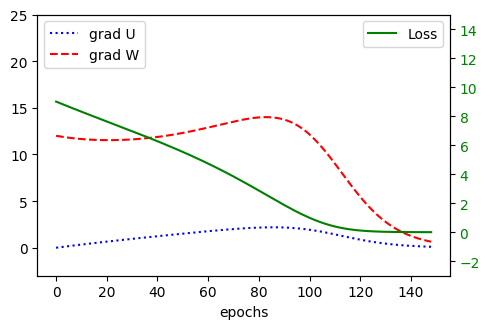

```python
# Use these inputs for normal training
# The first dimension represents the mini-batch
x = np.array([[0, 0, 0, 0, 1, 0, 1, 0, 1, 0]])
y = np.array([3])

print("Sum of ones RNN from scratch")

losses, gradients_u, gradients_w = train(x, y, epochs=150)
plot_training(losses, gradients_u, gradients_w)
```

```
y[0]: 12
s[-1, -1]: 0.0
y[0]: 12
s[-1, -1]: 0.04802766392524801
y[0]: 12
s[-1, -1]: 0.0961253085610661
y[0]: 12
s[-1, -1]: 0.1446525918818886
y[0]: 12
s[-1, -1]: 0.1939797347485874
y[0]: 12
s[-1, -1]: 0.2445010922175978
y[0]: 12
s[-1, -1]: 0.2966503120004496
y[0]: 12
s[-1, -1]: 0.3509183461560175
y[0]: 12
s[-1, -1]: 0.4078759498179951
y[0]: 12
s[-1, -1]: 0.46820292868236923
y[0]: 12
s[-1, -1]: 0.5327274275807735
y[0]: 12
s[-1, -1]: 0.6024802455573349
y[0]: 12
s[-1, -1]: 0.678772000852277
y[0]: 12
s[-1, -1]: 0.763305883956946
y[0]: 12
s[-1, -1]: 0.8583476288125823
y[0]: 12
s[-1, -1]: 0.9669913470816927
y[0]: 12
s[-1, -1]: 1.093594818975408
y[0]: 12
s[-1, -1]: 1.2445362880383077
y[0]: 12
s[-1, -1]: 1.4296415100541646
y[0]: 12
s[-1, -1]: 1.6651957064549494
```

[output cut: 246 more lines]

```
y[0]: 12
s[-1, -1]: nan
y[0]: 12
s[-1, -1]: nan
y[0]: 12
s[-1, -1]: nan
y[0]: 12
s[-1, -1]: nan
y[0]: 12
s[-1, -1]: nan
y[0]: 12
s[-1, -1]: nan
y[0]: 12
s[-1, -1]: nan
weights: (nan, nan)
```

```
C:\Users\od81hc\AppData\Local\Temp\ipykernel_42584\1820063810.py:7: RuntimeWarning: overflow encountered in multiply
  return x_t * U + s_t * W
C:\Users\od81hc\AppData\Local\Temp\ipykernel_42584\1406194472.py:12: RuntimeWarning: invalid value encountered in multiply
  gU += np.sum(gS * x[:, k - 1])
C:\Users\od81hc\AppData\Local\Temp\ipykernel_42584\1406194472.py:13: RuntimeWarning: invalid value encountered in multiply
  gW += np.sum(gS * s[:, k - 1])
```

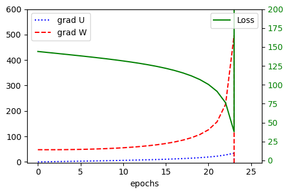

```python
x = np.array([[0, 0, 0, 0, 1, 0, 1, 0, 1, 0, 0, 0, 0, 0, 1, 0, 1, 0,
1, 0, 0, 0, 0, 0, 1, 0, 1, 0, 1, 0, 0, 0, 0, 0, 1, 0, 1, 0, 1, 0]])
y = np.array([12])
losses, gradients_u, gradients_w = train(x, y, epochs=150)
plot_training(losses, gradients_u, gradients_w, 600, 200)
```

Sau epoch thứ 23, đạo hàm trở nên quá lớn đến mức vượt quá phạm vi của biến số thực và trở thành NaN (như được minh họa bởi "cú nhảy" trong đồ thị). Vấn đề này được gọi là **bùng nổ gradient**. Nguyên nhân của những warning trong quá trình chạy chương trình bên trên là các tham số $U$ và $W$, trở nên quá lớn vượt quá ngưỡng của kiểu dữ liệu - Not a Number (NaN).

Bùng nổ gradient có thể xảy ra trong bất kỳ mạng nơ-ron sâu nào, nhưng đặc biệt rõ rệt trong **mạng nơ-ron hồi tiếp (RNNs)** do cách các mô hình này xử lý chuỗi theo thời gian.

**Độ sâu theo thời gian (Depth through Time)**

- Trong RNNs, cùng một tập hợp trọng số được áp dụng ở mỗi bước thời gian, tạo ra một mạng sâu *mở rộng theo thời gian*.
- Đối với một chuỗi đầu vào dài, có thể **hàng chục hoặc hàng trăm lớp** sâu, tùy thuộc vào độ dài chuỗi.
- Độ sâu này làm tăng nguy cơ bùng nổ gradient (tăng theo hàm mũ) hoặc **tiêu biến** (về "không").

**Tính toán độ dốc trong RNNs**

$$ \frac{\partial J}{\partial s_{t-1}} = \frac{\partial J}{\partial s_t} \cdot \frac{\partial s_t}{\partial s_{t-1}} = \frac{\partial J}{\partial s_t} \cdot W $$

- Đạo hàm tại mỗi bước thời gian phụ thuộc vào tích của nhiều ma trận Jacobian.
- Nếu các trị riêng của những ma trận này **lớn hơn 1**, tích có thể tăng theo hàm mũ → **bùng nổ gradient**.

**Chia sẻ tham số**

- RNNs sử dụng **cùng một tham số ở mỗi bước thời gian**, vì vậy bất kỳ sự mất ổn định nào cũng sẽ được **lặp lại và tích lũy**.
- Không giống như mạng feedforward, nơi các lớp khác nhau có thể "học" để cân bằng lẫn nhau, RNNs không có sự linh hoạt đó.

**Trí nhớ dài hạn**

- Cố gắng học các thông tin dài hạn trong chuỗi làm tăng độ dài tính toán của lan truyền ngược, làm tăng khả năng mất ổn định gradient.

Vì vậy,

- Mạng nơ-ron feedforward thông thường có độ sâu cố định, độ sâu thấp hơn.
- Các mạng feedforward rất sâu (ví dụ, hơn 100 lớp) cũng có thể gặp phải vấn đề bùng nổ gradient, nhưng vấn đề này **hiếm gặp hơn** và dễ dàng giảm thiểu với các kiến trúc hiện đại (ví dụ, ResNets, lớp chuẩn hóa).

$$ \frac{\partial s_t}{\partial s_{t-k}} = \prod_{j=1}^k \phi'(z_{t-j+1}) W = W^k $$

Trong một mạng **RNN tuyến tính đơn giản** với trọng số vô hướng $W$, đạo hàm giữa các bước thời gian cách xa nhau sẽ có dạng $W^k$. Điều này có nghĩa là nếu $|W| > 1$, đạo hàm tăng theo hàm mũ qua thời gian (bùng nổ gradient), và nếu $|W| < 1$, nó co lại theo hàm mũ (tiêu biến gradient).

Khi $W$ là một ma trận, điều này được tổng quát hóa: độ lớn của gradient bị ảnh hưởng bởi **bán kính phổ** $\rho(W)$, trị riêng tuyệt đối lớn nhất của $W$. Nếu $\rho(W) > 1$, các gradient có xu hướng bùng nổ, và nếu $\rho(W) < 1$, chúng có xu hướng **tiêu biến**, kết quả thực tế còn phụ thuộc vào hàm kích hoạt và các đạo hàm của nó.

# III. Full Computation - Backpropagation Through Time

Phần này minh họa quy trình tính toán đầy đủ cho Lan Truyền Ngược Qua Thời Gian (BPTT) trong Mạng Nơ-ron Hồi tiếp (RNNs). Chúng ta sẽ minh họa việc lưu trữ các trạng thái trung gian và luồng gradient qua các bước thời gian.

```python
import numpy as np
import matplotlib.pyplot as plt
from matplotlib.patches import Rectangle, FancyArrowPatch
import seaborn as sns
```

## 1. Giới thiệu Full Computation trong BPTT

Việc thực hiện full computation trong BPTT bao gồm việc tính tổng toàn bộ đạo hàm trong phương trình:

$$\frac{\partial h_t}{\partial w_h} = \frac{\partial f(x_t, h_{t-1}, w_h)}{\partial w_h} + \sum_{i=1}^{t-1}\left(\prod_{j=i+1}^{t}\frac{\partial f(x_j, h_{j-1}, w_h)}{\partial h_{j-1}}\right)\frac{\partial f(x_i, h_{i-1}, w_h)}{\partial w_h}$$

Với cách tiếp cận này:

- Tính toán các gradient qua *tất cả* các bước thời gian mà không cắt ngắn
- Lưu trữ tất cả các trạng thái trung gian để lan truyền ngược
- Nắm bắt các mối quan hệ dài hạn nhưng có thể dẫn đến:
  1. Sử dụng bộ nhớ cao
  2. Gradient tiêu biến/bùng nổ
  3. Nhạy cảm với việc khởi tạo ban đầu

## 2. Thực thi Full computation trong BPTT

```python
# Define activation functions
def tanh(x):
    return np.tanh(x)

def dtanh(x):
    return 1 - np.tanh(x)**2

# Model setup
class RNN:
    def __init__(self, input_size, hidden_size, output_size):
        # Initialize weights
        self.Wxh = np.random.randn(hidden_size, input_size) * 0.01
        self.Whh = np.random.randn(hidden_size, hidden_size) * 0.01
        self.Why = np.random.randn(output_size, hidden_size) * 0.01
        self.bh = np.zeros((hidden_size, 1))
        self.by = np.zeros((output_size, 1))

        # For storing intermediate states
        self.h_states = []
        self.h_raw = []
        self.y_preds = []

    def forward(self, x_sequence):
        # Initialize hidden state
        h = np.zeros((self.Whh.shape[0], 1))
        self.h_states = [h.copy()]
        self.h_raw = []
        self.y_preds = []

        # Forward pass through time
        for x in x_sequence:
            # Input to hidden
            h_raw = self.Wxh @ x + self.Whh @ h + self.bh
            h = tanh(h_raw)

            # Hidden to output
            y = self.Why @ h + self.by

            # Store all states
            self.h_raw.append(h_raw)
            self.h_states.append(h.copy())
            self.y_preds.append(y)

        return self.y_preds

    def backward(self, x_sequence, y_targets, learning_rate=0.01):
        # Initialize gradients
        dWxh = np.zeros_like(self.Wxh)
        dWhh = np.zeros_like(self.Whh)
        dWhy = np.zeros_like(self.Why)
        dbh = np.zeros_like(self.bh)
        dby = np.zeros_like(self.by)

        # Gradients of hidden state at t+1
        dh_next = np.zeros_like(self.h_states[0])

        # Log gradients for visualization
        gradient_magnitudes = []

        # Backpropagation through time
        T = len(x_sequence)
        for t in reversed(range(T)):
            # Gradient from output
            dy = self.y_preds[t] - y_targets[t]
            dWhy += dy @ self.h_states[t+1].T
            dby += dy

            # Gradient into hidden state: from output and from next time step
            dh = self.Why.T @ dy + dh_next

            # Gradient through tanh
            dh_raw = dtanh(self.h_raw[t]) * dh
            dbh += dh_raw

            # Gradient to weights
            dWxh += dh_raw @ x_sequence[t].T
            dWhh += dh_raw @ self.h_states[t].T

            # Gradient to previous hidden state
            dh_next = self.Whh.T @ dh_raw

            # Store gradient magnitude for visualization
            gradient_magnitudes.append(np.mean(np.abs(dh)))

        # Apply gradients
        self.Wxh -= learning_rate * dWxh
        self.Whh -= learning_rate * dWhh
        self.Why -= learning_rate * dWhy
        self.bh -= learning_rate * dbh
        self.by -= learning_rate * dby

        return gradient_magnitudes
```

## 3. Trực quan hóa Full computation trong BPTT

```python
def visualize_rnn_unfolding(sequence_length):
    """Visualize RNN unfolding through time with full computation"""
    plt.figure(figsize=(12, 6))

    # Parameters
    box_width = 1
    box_height = 1
    h_spacing = 2
    v_spacing = 1.5

    # Colors
    input_color = '#FFC107'  # amber
    hidden_color = '#2196F3'  # blue
    output_color = '#4CAF50'  # green
    arrow_color = '#9E9E9E'  # gray
    weight_color = '#E91E63'  # pink

    # Draw nodes and connections
    for t in range(sequence_length + 1):
        # Position for this time step
        x_pos = t * h_spacing

        if t < sequence_length:
            # Input node
            plt.gca().add_patch(Rectangle((x_pos, 0), box_width, box_height,
                                         facecolor=input_color, alpha=0.7, edgecolor='black'))
            plt.text(x_pos + box_width/2, box_height/2, f'$x_{t}$',
                     horizontalalignment='center', verticalalignment='center')

            # Output node
            plt.gca().add_patch(Rectangle((x_pos, 2*v_spacing), box_width, box_height,
                                         facecolor=output_color, alpha=0.7, edgecolor='black'))
            plt.text(x_pos + box_width/2, 2*v_spacing + box_height/2, f'$y_{t}$',
                     horizontalalignment='center', verticalalignment='center')

        # Hidden node
        plt.gca().add_patch(Rectangle((x_pos, v_spacing), box_width, box_height,
                                     facecolor=hidden_color, alpha=0.7, edgecolor='black'))
        plt.text(x_pos + box_width/2, v_spacing + box_height/2, f'$h_{t}$',
                 horizontalalignment='center', verticalalignment='center')

        if t < sequence_length:
            # Input to hidden connection
            arrow = FancyArrowPatch((x_pos + box_width/2, box_height),
                                  (x_pos + box_width/2, v_spacing),
                                  arrowstyle='->', color=arrow_color, linewidth=1.5)
            plt.gca().add_patch(arrow)
            plt.text(x_pos + box_width/2 - 0.2, box_height + (v_spacing - box_height)/2, '$W_{xh}$',
                    color=weight_color)

            # Hidden to output connection
            arrow = FancyArrowPatch((x_pos + box_width/2, v_spacing + box_height),
                                  (x_pos + box_width/2, 2*v_spacing),
                                  arrowstyle='->', color=arrow_color, linewidth=1.5)
            plt.gca().add_patch(arrow)
            plt.text(x_pos + box_width/2 - 0.2, v_spacing + box_height + (v_spacing - box_height)/2, '$W_{hy}$',
                    color=weight_color)

        # Recurrent connection (hidden to next hidden)
        if t < sequence_length:
            arrow = FancyArrowPatch((x_pos + box_width, v_spacing + box_height/2),
                                  (x_pos + h_spacing, v_spacing + box_height/2),
                                  arrowstyle='->', color=arrow_color, linewidth=1.5, linestyle='--')
            plt.gca().add_patch(arrow)
            plt.text(x_pos + box_width + (h_spacing - box_width)/2,
                    v_spacing + box_height/2 - 0.2, '$W_{hh}$', color=weight_color)

    # Draw backward pass
    for t in range(sequence_length-1, -1, -1):
        x_pos = t * h_spacing

        # Output to hidden backward
        arrow = FancyArrowPatch((x_pos + box_width/2, 2*v_spacing),
                              (x_pos + box_width/2, v_spacing + box_height),
                              arrowstyle='<-', color='red', linewidth=1.0, linestyle=':')
        plt.gca().add_patch(arrow)

        # Hidden to previous hidden backward
        if t > 0:
            arrow = FancyArrowPatch((x_pos, v_spacing + box_height/2),
                                  (x_pos - h_spacing + box_width, v_spacing + box_height/2),
                                  arrowstyle='<-', color='red', linewidth=1.0, linestyle=':')
            plt.gca().add_patch(arrow)

    # Label the backward arrows at the end
    plt.text(0.5 * h_spacing, 2*v_spacing - 0.2, r'$\frac{\partial L}{\partial y_t}$', color='red')
    plt.text(1.5 * h_spacing, v_spacing + 0.3, r'$\frac{\partial L}{\partial h_t}$', color='red')

    # Add title and adjust plot
    plt.title('Full Computation in BPTT: Unfolding RNN Through Time')
    plt.xlim(-0.5, sequence_length * h_spacing + 1)
    plt.ylim(-0.5, 3 * v_spacing)
    plt.axis('off')

    # Add a legend for forward and backward passes
    arrow_f = FancyArrowPatch((0, 0), (0.5, 0), arrowstyle='->', color=arrow_color, linewidth=1.5)
    arrow_b = FancyArrowPatch((0, 0), (0.5, 0), arrowstyle='<-', color='red', linewidth=1.0, linestyle=':')
    plt.legend([arrow_f, arrow_b], ['Forward Pass', 'Backward Pass'],
              loc='upper center', bbox_to_anchor=(0.5, -0.05), ncol=2)

    plt.tight_layout()
    plt.show()
```

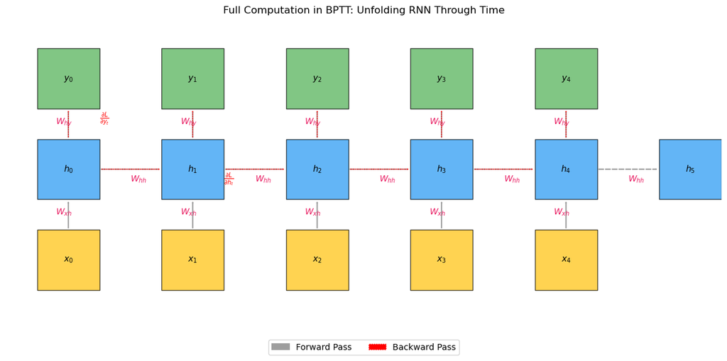

```python
# Visualize full BPTT unfolding for a sequence of length 5
visualize_rnn_unfolding(5)
```

## 4. Minh họa kết quả Full Computation trong BPTT

```python
def run_gradient_experiment(sequence_lengths=[5, 10, 20, 50]):
    """Run experiments showing gradient behavior for different sequence lengths"""
    # Parameters
    input_size = 1
    hidden_size = 4
    output_size = 1

    # Results storage
    all_gradients = {}

    for seq_len in sequence_lengths:
        # Create a simple sine wave sequence
        x = np.linspace(0, 4*np.pi, seq_len)
        x_sequence = [np.array([[np.sin(val)]]) for val in x]
        y_targets = [np.array([[np.sin(val + 0.1)]]) for val in x]  # Shifted sine

        # Initialize RNN
        rnn = RNN(input_size, hidden_size, output_size)

        # Forward and backward passes
        rnn.forward(x_sequence)
        gradient_magnitudes = rnn.backward(x_sequence, y_targets)

        # Store results
        all_gradients[seq_len] = gradient_magnitudes

    # Visualization of gradient magnitudes
    plt.figure(figsize=(10, 6))

    for seq_len, grads in all_gradients.items():
        # Reverse to show gradients from start to end
        plt.plot(list(range(seq_len)), grads[::-1], label=f'Sequence Length: {seq_len}')

    plt.xlabel('Time Step')
    plt.ylabel('Average Gradient Magnitude')
    plt.title('Gradient Magnitudes in Full BPTT by Sequence Length')
    plt.legend()
    plt.grid(True, alpha=0.3)
    plt.yscale('log')  # Log scale to show vanishing gradients
    plt.tight_layout()
    plt.show()

    return all_gradients
```

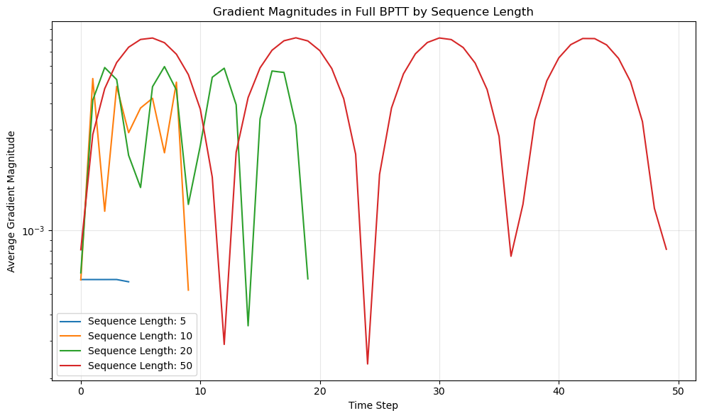

```python
# Run gradient experiment
gradient_results = run_gradient_experiment()
```

## 5. Những Thách Thức Của Tính Toán Đầy Đủ

Những thách thức này thường khiến các nghiên cứu và vận hành thực tế phải sử dụng các phương pháp thay thế như BPTT cắt ngắn hoặc các giải pháp kiến trúc khác như LSTM/GRU.

## 6. Minh họa lưu trữ trong bộ nhớ

Một khía cạnh quan trọng của tính toán đầy đủ là cần phải lưu trữ tất cả các trạng thái trung gian. Có thể thấy qua kết quả bên dưới:

```python
def visualize_memory_storage(sequence_length):
    """Visualize memory storage requirements for full BPTT"""
    plt.figure(figsize=(10, 6))

    # Generate data
    hidden_sizes = [4, 16, 64, 256]
    memory_usage = [[h_size * seq_len for seq_len in range(1, sequence_length+1)] for h_size in hidden_sizes]

    # Plot memory usage
    for i, h_size in enumerate(hidden_sizes):
        plt.plot(range(1, sequence_length+1), memory_usage[i], label=f'Hidden Size: {h_size}')

    plt.xlabel('Sequence Length')
    plt.ylabel('Relative Memory Units')
    plt.title('Memory Storage Requirements for Full BPTT')
    plt.legend()
    plt.grid(True, alpha=0.3)
    plt.tight_layout()
    plt.show()
```

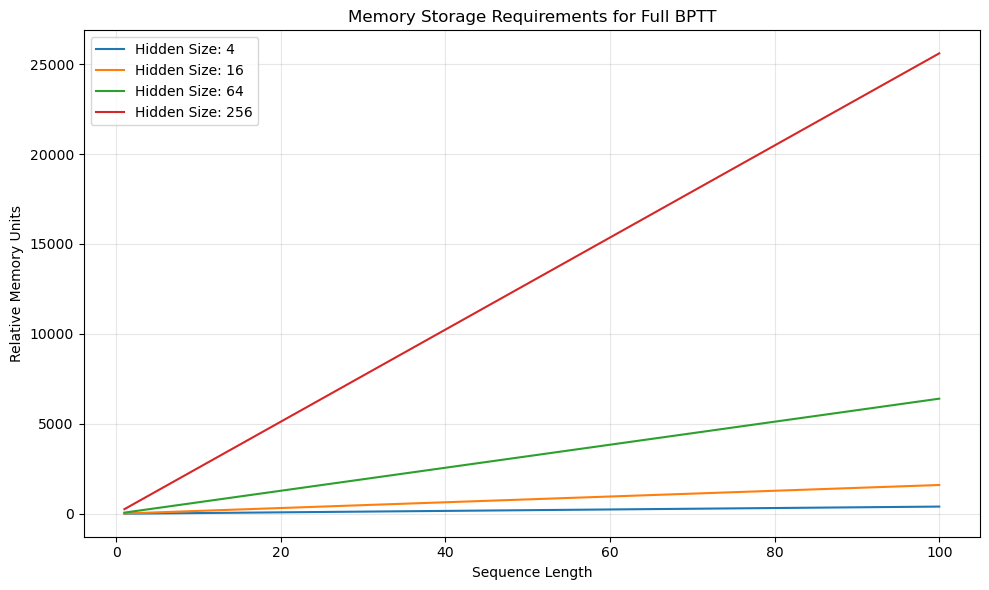

```python
# Visualize memory storage for sequence lengths up to 100
visualize_memory_storage(100)
```

## 7. Kết luận

Tính toán đầy đủ trong BPTT cung cấp các ước lượng gradient chính xác nhất nhưng đi kèm với những thách thức đáng kể:

- Nó yêu cầu lưu trữ tất cả các trạng thái trung gian, điều này tăng theo độ dài chuỗi.
- Nó gặp phải vấn đề gradient tiêu biến và bùng nổ đối với các chuỗi dài.
- Nó rất tốn kém về mặt tính toán đối với các chuỗi dài.

Những thách thức này thường dẫn đến việc sử dụng BPTT cắt ngắn trong thực tế, hoặc các kiến trúc chuyên biệt như LSTM và GRU được thiết kế để giảm thiểu các vấn đề này.

Mặc dù tính toán đầy đủ về lý thuyết là hoàn hảo cho gradient với độ chính xác cao, nhưng các kiểm nghiệm thực tiễn cho thấy không khả thi khi thực hiện tính toán đầy đủ đối với các tác vụ liên quan đến chuỗi rất dài.

# IV. Giải pháp và Các phương pháp huấn luyện khác

## 1. Giải pháp xử lý vanishing/exploding gradients bằng Truncated BPTT

Truncated Backpropagation Through Time (TBPTT) là một phương pháp tối ưu hóa quá trình huấn luyện các mạng nơ-ron hồi tiếp (RNN) trên các chuỗi dữ liệu dài, bằng cách chia chuỗi đầu vào thành các đoạn con (subsequences) có độ dài cố định.

### 1.1. Nguyên lý hoạt động

- Forward pass:
  - Mỗi đoạn con được xử lý tuần tự. Trạng thái ẩn (hidden state) từ đoạn con trước được truyền sang làm giá trị khởi tạo cho đoạn con tiếp theo.
  - Ví dụ: Nếu chuỗi gốc dài 100 bước thời gian được chia thành 4 đoạn (mỗi đoạn 25 bước), hidden state ở bước 25 sẽ dùng làm đầu vào cho đoạn 26–50.
- Backward pass:
  - Gradient chỉ được tính toán trong phạm vi từng đoạn con và bị "cắt bỏ" (truncated) khi chuyển sang đoạn tiếp theo.
  - Khác với BPTT tiêu chuẩn (gradient lan truyền qua toàn bộ chuỗi), TBPTT ngăn gradient từ đoạn sau ảnh hưởng đến đoạn trước nếu vượt quá độ dài đoạn con.

### 1.2. Ưu điểm của phương pháp trên

##### Hạn chế:

- Việc giới hạn số bước khiến cho các phụ thuộc từ đầu chuỗi không được xét đến, dẫn đến giảm hiệu suất trong các tác vụ yêu cầu bộ nhớ dài
- Gradient tính toán không chính xác như Full Computation, nhưng vẫn đủ tốt để huấn luyện hiệu quả

### 1.3. Ứng dụng thực tế

- Mô hình ngôn ngữ (Language Models): xử lý văn bản dài
- Dự báo chuỗi thời gian: Dự báo giá cổ phiếu, thời tiết
- Xử lý âm thanh: Nhận dạng giọng nói

### 1.4. Hiện thực

```python
import numpy as np
import torch
import torch.nn as nn
import torch.optim as optim
import matplotlib.pyplot as plt
import time
import psutil
device = torch.device('cuda' if torch.cuda.is_available() else 'cpu')
```

- **Trong đó**:
  - `numpy`: Tạo dữ liệu sóng sine.
  - `torch`: Xây dựng và huấn luyện RNN.
  - `matplotlib`: Vẽ biểu đồ loss.
  - `time`, `psutil`: Đo thời gian và bộ nhớ.
  - `device`: Sử dụng GPU nếu có, nếu không dùng CPU.

Ta sẽ tạo một chuỗi sóng sine với nhiễu Gaussian để huấn luyện mô hình

```python
def generate_data(seq_length=10000):
    t = np.linspace(0, 100, seq_length)
    y = np.sin(t) + 0.1 * np.random.randn(seq_length)
    return y
```

- **Tham số**:
  - `seq_length=10000`: Độ dài chuỗi.
  - `t`: Chuỗi thời gian từ 0 đến 100.
  - `y`: Sóng sine với nhiễu (độ lệch chuẩn 0.1).
- **Mục đích**: Tạo dữ liệu mô phỏng chuỗi thời gian thực tế.

Tiếp theo, ta xây dựng mô hình RNN đơn giản sử dụng nn.Module của PyTorch với một hidden layer và một linear layer để dự đoán:

```python
class RNN(nn.Module):
    def __init__(self, input_size=1, hidden_size=32):
        super(RNN, self).__init__()
        self.rnn = nn.RNN(input_size, hidden_size, batch_first=True)
        self.fc = nn.Linear(hidden_size, 1)

    def forward(self, x, h=None):
        out, h = self.rnn(x, h)
        out = self.fc(out)
        return out, h
```

- **Cấu trúc**:
  - `input_size=1`: Mỗi bước thời gian nhận một giá trị.
  - `hidden_size=32`: Kích thước lớp ẩn.
  - `batch_first=True`: Đầu vào có dạng (batch_size, seq_length, input_size).
  - `fc`: Lớp tuyến tính ánh xạ từ lớp ẩn sang đầu ra.
- **Hàm forward**: Trả về dự đoán và trạng thái ẩn.

Để huấn luyện mô hình, ta định nghĩa Hàm `train` hỗ trợ cả Full BPTT và Truncated BPTT, đồng thời đo lường thời gian và bộ nhớ.

```python
def train(model, data, truncate_length=200, num_epochs=30, lr=0.01, is_truncate=True):
    optimizer = optim.Adam(model.parameters(), lr=lr)
    criterion = nn.MSELoss()
    losses = []

    model.train()

    # Đo thời gian bắt đầu
    start_time = time.time()

    # Đo bộ nhớ ban đầu
    process = psutil.Process()
    mem_before = process.memory_info().rss / 1024 / 1024  # MB

    # Đo bộ nhớ GPU ban đầu
    if torch.cuda.is_available():
        gpu_mem_before = torch.cuda.memory_allocated() / 1024 ** 2  # MB
        gpu_reserved_before = torch.cuda.memory_reserved() / 1024 ** 2  # MB
    else:
        gpu_mem_before = 0.0
        gpu_reserved_before = 0.0

    seq_len = len(data)-1
    data = np.array(data)
    data_tensor = torch.tensor(data, dtype=torch.float32, device=device)

    if is_truncate:
        # Truncated BPTT
        for epoch in range(num_epochs):
            optimizer.zero_grad()
            h = None
            total_loss = 0.0
            num_steps = 0

            for start in range(0, seq_len, truncate_length):
                end = min(start + truncate_length, seq_len)
                segment_length = end - start
                x = data_tensor[start:end].unsqueeze(0).unsqueeze(-1)
                y_true = data_tensor[start+1:end+1].unsqueeze(0).unsqueeze(-1)

                y_pred, h = model(x, h)
                loss = criterion(y_pred, y_true)
                scaled_loss = loss*segment_length/seq_len
                scaled_loss.backward()
                total_loss += (loss*segment_length).item()
                num_steps += segment_length
                h = h.detach()

            optimizer.step()
            avg_loss = total_loss / num_steps
            losses.append(avg_loss)

            if (epoch + 1) % 5 == 0:
                print(f"Epoch {epoch + 1}/{num_epochs}, Loss: {avg_loss:.6f}")
    else:
        # Full BPTT
        x = data_tensor[:-1].unsqueeze(0).unsqueeze(-1)
        y_true = data_tensor[1:].unsqueeze(0).unsqueeze(-1)

        for epoch in range(num_epochs):
            model.zero_grad()
            y_pred, _ = model(x)
            loss = criterion(y_pred, y_true)
            loss.backward()
            optimizer.step()
            losses.append(loss.item())

            if (epoch + 1) % 5 == 0:
                print(f"Epoch {epoch + 1}/{num_epochs}, Loss: {loss.item():.6f}")

    # Đo thời gian kết thúc
    end_time = time.time()
    elapsed_time = end_time - start_time

    # Đo bộ nhớ GPU sau huấn luyện
    if torch.cuda.is_available():
        gpu_mem_after = torch.cuda.memory_allocated() / 1024 ** 2  # MB
        gpu_reserved_after = torch.cuda.memory_reserved() / 1024 ** 2  # MB
    else:
        gpu_mem_after = 0.0
        gpu_reserved_after = 0.0

    # Tính bộ nhớ GPU sử dụng
    gpu_mem_used = gpu_mem_after - gpu_mem_before
    gpu_reserved_used = gpu_reserved_after - gpu_reserved_before

    # Đo bộ nhớ sau huấn luyện
    mem_after = process.memory_info().rss / 1024 / 1024  # MB
    mem_used = mem_after - mem_before

    return losses, elapsed_time, mem_used, gpu_mem_used, gpu_reserved_used
```

- **Tham số**:
  - `truncate_length=200`: Độ dài đoạn cho Truncated BPTT.
  - `num_epochs=30`: Số epoch huấn luyện.
  - `lr=0.01`: Tốc độ học.
  - `is_truncate`: Chọn giữa Truncated BPTT (`True`) và Full BPTT (`False`).
- **Đo lường**:
  - Thời gian huấn luyện (giây).
  - Bộ nhớ CPU và GPU sử dụng (MB).
- **Trả về**: Danh sách loss, thời gian, bộ nhớ CPU/GPU sử dụng.

Sau khi định nghĩa xong các lớp và hàm cần thiết, ta tiến hành huấn luyện hai mô hình: một với Truncated BPTT (độ dài truncate 200) và một với Full BPTT.

```python
data = generate_data()
# Huấn luyện với truncated BPTT
print("Fix Truncate BPTT")
model_truncated = RNN().to(device)
losses_truncated, time_truncated, memory_truncated, gpu_mem_truncated, gpu_reserved_truncated = train(model_truncated, data)

# Huấn luyện với full BPTT
print("Full BPTT")
model_standard = RNN().to(device)
losses_standard, time_standard, memory_standard, gpu_mem_standard, gpu_reserved_standard = train(model_standard, data, is_truncate=False)
```

```
Fix Truncate BPTT
Full BPTT
```

`Biểu đồ loss` được vẽ để so sánh tốc độ hội tụ của hai phương pháp

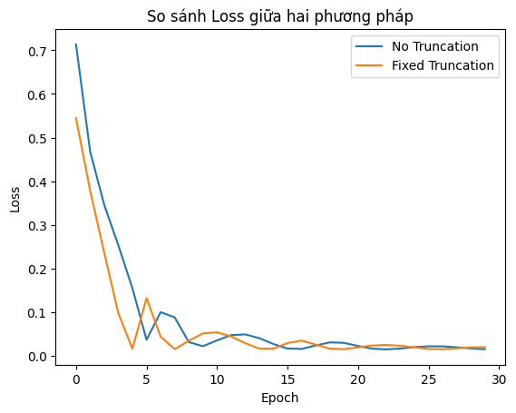

```python
plt.plot(losses_standard, label="No Truncation")
plt.plot(losses_truncated, label="Fixed Truncation")
plt.xlabel("Epoch")
plt.ylabel("Loss")
plt.legend()
plt.title("So sánh Loss giữa hai phương pháp")
plt.show()
```

Kết quả về thời gian và bộ nhớ được in ra để so sánh.

```python
print("\n==== Kết Quả ====")
print(f"[No Truncation]    Thời gian: {time_standard:.2f} giây, Bộ nhớ tăng (CPU): {memory_standard:.2f} MB")
print(f"[Fix Truncation] Thời gian: {time_truncated:.2f} giây, Bộ nhớ tăng (CPU): {memory_truncated:.2f} MB")

if torch.cuda.is_available():
    print("\n==== Thống kê GPU (kèm thời gian huấn luyện) ====")
    print(f"[No Truncation]    Thời gian: {time_standard:.2f} giây | Bộ nhớ GPU sử dụng: {gpu_mem_standard:.2f} MB | Bộ nhớ GPU reserved: {gpu_reserved_standard:.2f} MB")
    print(f"[Fix Truncation] Thời gian: {time_truncated:.2f} giây | Bộ nhớ GPU sử dụng: {gpu_mem_truncated:.2f} MB | Bộ nhớ GPU reserved: {gpu_reserved_truncated:.2f} MB")
```

```
==== Kết Quả ====
[No Truncation]    Thời gian: 0.29 giây, Bộ nhớ tăng (CPU): 38.92 MB
[Fix Truncation] Thời gian: 1.74 giây, Bộ nhớ tăng (CPU): 240.78 MB

==== Thống kê GPU (kèm thời gian huấn luyện) ====
[No Truncation]    Thời gian: 0.29 giây | Bộ nhớ GPU sử dụng: 0.13 MB | Bộ nhớ GPU reserved: 24.00 MB
[Fix Truncation] Thời gian: 1.74 giây | Bộ nhớ GPU sử dụng: 16.31 MB | Bộ nhớ GPU reserved: 40.00 MB
```

Cuối cùng, Chúng ta so sánh hiệu suất của Truncated BPTT với các độ dài truncate khác nhau để đánh giá tác động của tham số này.

```python
def compare_bptt_methods():
    device = torch.device("cuda" if torch.cuda.is_available() else "cpu")
    data = generate_data()

    # List of configurations to compare
    methods = [
        {"name": "Full BPTT", "is_truncate": False},
        {"name": "Truncate_20", "is_truncate": True, "truncate_length": 20},
        {"name": "Truncate_50", "is_truncate": True, "truncate_length": 50},
        {"name": "Truncate_100", "is_truncate": True, "truncate_length": 100},
        {"name": "Truncate_200", "is_truncate": True, "truncate_length": 200},
        {"name": "Truncate_500", "is_truncate": True, "truncate_length": 500},
        {"name": "Truncate_1000", "is_truncate": True, "truncate_length": 1000},
        {"name": "Truncate_5000", "is_truncate": True, "truncate_length": 5000},
        {"name": "Truncate_10000", "is_truncate": True, "truncate_length": 10000},
    ]

    results = []
    for method in methods:
        print(f"\nTraining with {method['name']}")
        model = RNN().to(device)
        if method["is_truncate"]:
            losses, time_taken, mem_used, gpu_mem_used, gpu_reserved_used = train(
                model, data, truncate_length=method["truncate_length"], is_truncate=True
            )
        else:
            losses, time_taken, mem_used, gpu_mem_used, gpu_reserved_used = train(
                model, data, is_truncate=False
            )
        results.append({
            "name": method["name"],
            "losses": losses,
            "time": time_taken,
            "mem_used": mem_used,
            "gpu_mem_used": gpu_mem_used,
            "gpu_reserved_used": gpu_reserved_used
        })

    # Print summary
    print("\n==== Summary ====")
    print("Method\t\tTime (s)\tCPU Mem (MB)")
    print("-" * 60)
    for result in results:
        print(f"{result['name']:<15}\t{result['time']:.2f}\t\t{result['mem_used']:.2f}")

compare_bptt_methods()
```

```
Training with Full BPTT

Training with Truncate_20

Training with Truncate_50

Training with Truncate_100

Training with Truncate_200

Training with Truncate_500

Training with Truncate_1000

Training with Truncate_5000

Training with Truncate_10000

==== Summary ====
Method		Time (s)	CPU Mem (MB)
------------------------------------------------------------
Full BPTT      	0.58		1.05
Truncate_20    	74.45		0.03
Truncate_50    	30.73		0.02
Truncate_100   	3.46		0.12
Truncate_200   	1.84		0.02
Truncate_500   	0.78		0.02
Truncate_1000  	0.45		0.06
Truncate_5000  	0.24		0.09
Truncate_10000 	0.28		0.00
```

## 2. Giải pháp xử lý vanishing/exploding gradients bằng Truncated BPTT: **Randomized Truncation**

### 2.1. Nguyên lý hoạt động

**Randomized Truncation** là một kỹ thuật giúp giảm chi phí tính toán khi huấn luyện mạng RNN (Recurrent Neural Network). Cụ thể, thay vì tính chuỗi gradient đầy đủ qua tất cả các bước thời gian (rất tốn kém), ta sẽ ngẫu nhiên dừng lại ở một số bước nhưng vẫn đảm bảo rằng kỳ vọng của gradient không thay đổi (tức là trung bình kết quả vẫn đúng).

Đạo hàm chuẩn (gradient chuẩn) cần tính trong RNN là:

$$ \frac{\partial h_t}{\partial w_h} $$

Thay vì tính toàn bộ biểu thức này, ta thay thế bằng một giá trị xấp xỉ, ký hiệu là $z_{t}$, với công thức:

$$ z_t = \frac{\partial f(x_{t}, h_{t-1}, w_h)}{\partial w_h} + \xi_t \frac{\partial f(x_{t}, h_{t-1}, w_h)}{\partial h_{t-1}} \cdot \frac{\partial h_{t-1}}{\partial w_h} $$

Trong đó:

- $f(x_{t},h_{t-1},w_h)$ là hàm cập nhật trạng thái trong RNN.
- $\xi_t$ là một biến ngẫu nhiên nhận giá trị:
  - 0 với xác suất $P(\xi_t = 0) = 1-\pi_t$
  - $\pi_t^{-1}$ với xác suất $P(\xi_t = \pi_t^{-1}) = \pi_t$

Do đó, kỳ vọng của $\xi_t$ là: \begin{equation} E[z_t] = 0 ⋅(1-\pi_t)+ \frac{1}{\pi_t} ⋅\pi_t = 1 \end{equation}

→ Dẫn đến kỳ vọng của $z_{t}$ vẫn là gradient đầy đủ:

\begin{equation} E[z_t] = \frac{\partial h_t}{\partial w_h} \end{equation}

Bất cứ khi nào $\xi_t = 0$ tính toán tái phát chấm dứt tại thời điểm đó bước $t$. Điều này dẫn đến một tổng có trọng số của các chuỗi có độ dài khác nhau, trong đó các chuỗi dài tuy hiếm gặp nhưng lại được gán trọng số lớn một cách phù hợp.

### 2.2. Ưu điểm của Randomized Truncation

1. Giảm chi phí tính toán
- Thay vì phải lan truyền ngược qua toàn bộ chuỗi thời gian (có thể dài hàng trăm bước), thuật toán này chỉ lan truyền ngược một phần chuỗi ngẫu nhiên.
- Giảm đáng kể thời gian huấn luyện và mức tiêu thụ bộ nhớ (RAM/GPU).
2. Tránh vanishing/exploding gradient
- Trong mạng RNN truyền thống, việc lan truyền gradient qua nhiều bước khiến giá trị đạo hàm rất nhỏ (vanishing gradient) hoặc rất lớn (exploding gradient).
- Randomized truncation giới hạn độ sâu lan truyền, giúp gradient ổn định hơn.
3. Giữ nguyên độ chính xác theo kỳ vọng
- Mặc dù cắt chuỗi ngẫu nhiên, thuật toán vẫn đảm bảo kỳ vọng của gradient đúng: \begin{equation} E[z_t] = \frac{\partial h_t}{\partial w_h} \end{equation}
4. Tăng khả năng tổng quát
- Việc ngẫu nhiên hóa độ dài chuỗi huấn luyện tương đương với một dạng regularization (giống như dropout), có thể giúp mô hình tổng quát tốt hơn trên dữ liệu mới.
5. Dễ triển khai, không cần thay đổi kiến trúc mạng
- Kỹ thuật này chỉ thay đổi cách lan truyền ngược gradient, không cần sửa đổi mô hình hay thêm thành phần phức tạp nào.
- Có thể tích hợp dễ dàng vào các pipeline huấn luyện RNN hiện có (như PyTorch, TensorFlow).
5. Hiệu quả với chuỗi rất dài
- Với dữ liệu thời gian hoặc chuỗi văn bản dài (ví dụ: hàng nghìn bước), đây là một giải pháp thực tế thay vì huấn luyện full BPTT (Backpropagation Through Time) quá nặng.

### 2.3. Hạn chế của Randomized Truncation

- Do quá trình backpropagation có thể bị cắt sớm ngẫu nhiên, các mối quan hệ phụ thuộc dài hạn trong chuỗi có thể bị bỏ sót.
- Do tính ngẫu nhiên trong việc cắt gradient, kết quả huấn luyện có thể dao động đáng kể giữa các lần huấn luyện khác nhau nếu không cố định seed.
- Nếu chọn $\pi_t$ quá nhỏ → mô hình cắt sớm quá thường xuyên → học chưa đủ.
- Nếu $\pi_t$ quá lớn → gần giống như backprop đầy đủ → mất ưu điểm giảm chi phí.
- Việc chọn $\pi_t$ phù hợp phụ thuộc vào bài toán cụ thể, và thường cần thử nghiệm (hyperparameter tuning).
- Gradient nhiễu, hội tụ chậm
- Chưa được hỗ trợ sẵn trong framework

### 2.4. Ví dụ bài toán: Dự đoán giá trị trong chuỗi thời gian

Ta xét bài toán dự đoán giá trị tiếp theo trong một chuỗi sin bị nhiễu: \begin{equation} y_t = sin(t) + noise \end{equation}

Sử dụng một RNN đơn giản (1 layer), ta huấn luyện để dự đoán $y_{t+1}$ dựa trên lịch sử $y_0,⋯,y_t$

### 2.5. Kế hoạch triển khai

1. Tạo chuỗi dữ liệu sin bị nhiễu.
2. Xây dựng RNN đơn giản.
3. Viết lại vòng lặp training để chèn Randomized Truncation.
4. So sánh:

```
*   Huấn luyện không truncate (chuẩn).
*   Huấn luyện có Randomized Truncation.
```

5. Vẽ đồ thị Loss vs Epoch.

Bắt đầu viết Code Python

```python
import numpy as np
import torch
import torch.nn as nn
import torch.optim as optim
import matplotlib.pyplot as plt
import time
import psutil  # để đo bộ nhớ CPU

# Bước 1: Xác định device
device = torch.device('cuda' if torch.cuda.is_available() else 'cpu')
print(f"Đang sử dụng: {device}")
```

```
Đang sử dụng: cuda
```

Tạo dữ liệu chuỗi sin bị nhiễu

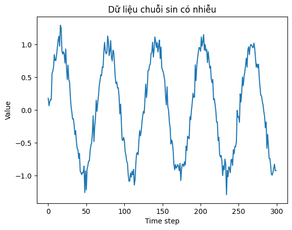

```python
# Tạo dữ liệu sin với noise
def generate_data(seq_length=1000):
    t = np.linspace(0, 100, seq_length)
    y = np.sin(t) + 0.1 * np.random.randn(seq_length)  # sin + noise
    return y

# Dữ liệu
data = generate_data()
plt.plot(data[:300])
plt.title("Dữ liệu chuỗi sin có nhiễu")
plt.xlabel("Time step")
plt.ylabel("Value")
plt.show()
```

Xây dựng mô hình RNN đơn giản

```python
# Mô hình RNN đơn giản
class SimpleRNN(nn.Module):
    def __init__(self, input_size=1, hidden_size=20):
        super(SimpleRNN, self).__init__()
        self.rnn = nn.RNN(input_size, hidden_size, batch_first=True)
        self.fc = nn.Linear(hidden_size, 1)

    def forward(self, x, h=None):
        out, h = self.rnn(x, h)
        out = self.fc(out)
        return out, h
```

Hàm training với tùy chọn Randomized Truncation

```python
# Hàm training có đo thời gian và bộ nhớ
def train(model, data, use_randomized_truncation=False, pi=0.9, num_epochs=30, lr=0.01):
    optimizer = optim.Adam(model.parameters(), lr=lr)
    criterion = nn.MSELoss()
    losses = []

    model.train()

    # Đo thời gian bắt đầu
    start_time = time.time()

    # Đo bộ nhớ ban đầu
    process = psutil.Process()
    mem_before = process.memory_info().rss / 1024 / 1024  # MB

    # Đo bộ nhớ GPU ban đầu
    if torch.cuda.is_available():
        gpu_mem_before = torch.cuda.memory_allocated() / 1024 ** 2  # MB
        gpu_reserved_before = torch.cuda.memory_reserved() / 1024 ** 2  # MB
    else:
        gpu_mem_before = 0.0
        gpu_reserved_before = 0.0

    for epoch in range(num_epochs):
        optimizer.zero_grad()

        h = None
        loss_epoch = 0
        count = 0

        for t in range(len(data)-1):
            x = torch.tensor([[data[t]]], dtype=torch.float32).unsqueeze(0).to(device)  # (batch, seq_len, input_size)
            y_true = torch.tensor([[data[t+1]]], dtype=torch.float32).unsqueeze(0).to(device)

            y_pred, h = model(x, h)

            loss = criterion(y_pred, y_true)
            loss_epoch += loss

            # Randomized truncation
            if use_randomized_truncation:
                if np.random.rand() > pi:
                    h = h.detach()

            count += 1

        loss_epoch = loss_epoch / count
        loss_epoch.backward()
        optimizer.step()
        losses.append(loss_epoch.item())

        if (epoch+1) % 5 == 0:
            print(f"Epoch {epoch+1}/{num_epochs}, Loss: {loss_epoch.item():.6f}")

    # Đo thời gian kết thúc
    end_time = time.time()
    elapsed_time = end_time - start_time

    # Đo bộ nhớ GPU sau huấn luyện
    if torch.cuda.is_available():
        gpu_mem_after = torch.cuda.memory_allocated() / 1024 ** 2  # MB
        gpu_reserved_after = torch.cuda.memory_reserved() / 1024 ** 2  # MB
    else:
        gpu_mem_after = 0.0
        gpu_reserved_after = 0.0

    # Tính bộ nhớ GPU sử dụng
    gpu_mem_used = gpu_mem_after - gpu_mem_before
    gpu_reserved_used = gpu_reserved_after - gpu_reserved_before

    # Đo bộ nhớ sau huấn luyện
    mem_after = process.memory_info().rss / 1024 / 1024  # MB
    mem_used = mem_after - mem_before

    return losses, elapsed_time, mem_used, gpu_mem_used, gpu_reserved_used
```

Giải thích:

- Với use_randomized_truncation=True, tại mỗi bước $t$, xác suất $1-\pi_t$ sẽ cắt đứt backpropagation (bằng .detach()).
- Nếu không, để gradient lan truyền bình thường.
- Cuối mỗi epoch, tính Loss trung bình và lưu lại để vẽ biểu đồ.

Huấn luyện mô hình và so sánh

```
Training WITHOUT Randomized Truncation...

Training WITH Randomized Truncation (pi=0.9)...
```

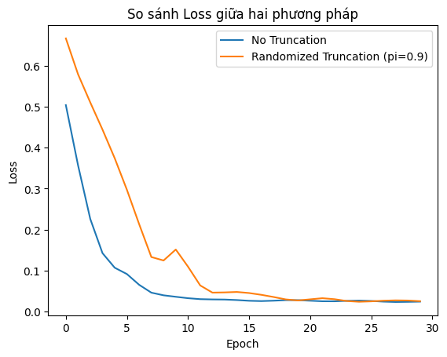

```
==== Tổng Kết ====
[No Truncation]    Thời gian: 226.61 giây, Bộ nhớ tăng (CPU): 17.61 MB
[Random Truncation] Thời gian: 44.71 giây, Bộ nhớ tăng (CPU): 1.30 MB

==== Thống kê GPU (kèm thời gian huấn luyện) ====
[No Truncation]    Thời gian: 226.61 giây | Bộ nhớ GPU sử dụng: 0.02 MB | Bộ nhớ GPU reserved: 2.00 MB
[Random Truncation] Thời gian: 44.71 giây | Bộ nhớ GPU sử dụng: 0.02 MB | Bộ nhớ GPU reserved: 0.00 MB
```

```python
# --- Chạy và so sánh ---
data = generate_data()

# Huấn luyện model không truncate
print("Training WITHOUT Randomized Truncation...")
model_standard = SimpleRNN().to(device)
losses_standard, time_standard, memory_standard, gpu_mem_standard, gpu_reserved_standard = train(model_standard, data, use_randomized_truncation=False)

# Huấn luyện model có truncate
print("\nTraining WITH Randomized Truncation (pi=0.9)...")
model_truncated = SimpleRNN().to(device)
losses_truncated, time_truncated, memory_truncated, gpu_mem_truncated, gpu_reserved_truncated = train(model_truncated, data, use_randomized_truncation=True, pi=0.9)

# Vẽ biểu đồ Loss
plt.plot(losses_standard, label="No Truncation")
plt.plot(losses_truncated, label="Randomized Truncation (pi=0.9)")
plt.xlabel("Epoch")
plt.ylabel("Loss")
plt.legend()
plt.title("So sánh Loss giữa hai phương pháp")
plt.show()

# In kết quả tổng hợp
print("\n==== Tổng Kết ====")
print(f"[No Truncation]    Thời gian: {time_standard:.2f} giây, Bộ nhớ tăng (CPU): {memory_standard:.2f} MB")
print(f"[Random Truncation] Thời gian: {time_truncated:.2f} giây, Bộ nhớ tăng (CPU): {memory_truncated:.2f} MB")

# In bộ nhớ GPU tổng thể kèm theo thời gian huấn luyện
if torch.cuda.is_available():
    print("\n==== Thống kê GPU (kèm thời gian huấn luyện) ====")
    print(f"[No Truncation]    Thời gian: {time_standard:.2f} giây | Bộ nhớ GPU sử dụng: {gpu_mem_standard:.2f} MB | Bộ nhớ GPU reserved: {gpu_reserved_standard:.2f} MB")
    print(f"[Random Truncation] Thời gian: {time_truncated:.2f} giây | Bộ nhớ GPU sử dụng: {gpu_mem_truncated:.2f} MB | Bộ nhớ GPU reserved: {gpu_reserved_truncated:.2f} MB")
```

Giải thích kết quả

- **Loss không truncate:** thường thấp hơn một chút, do sử dụng toàn bộ thông tin quá khứ.
- **Loss Randomized Truncation:** có thể dao động hơn, nhưng lại giúp:
  - Tiết kiệm bộ nhớ.
  - Training nhanh hơn.
  - Tránh vanishing gradient trong chuỗi quá dài.

```python
# Dự đoán giá trị tiếp theo
model_truncated.eval()  # Chuyển mô hình sang chế độ đánh giá
with torch.no_grad():  # Tắt gradient khi dự đoán
    x_input = torch.tensor([[data[-1]]], dtype=torch.float32).unsqueeze(0).to(device)  # Dữ liệu đầu vào
    y_pred, _ = model_truncated(x_input, h=None)  # Dự đoán giá trị tiếp theo
    print(f"Dự đoán giá trị tiếp theo: {y_pred.item():.6f}")
```

```
Dự đoán giá trị tiếp theo: -0.343403
```

# 1. Ứng dụng BPTT trong Language Modeling

## 1.1. Bài toán Language Modeling là gì?

**Language modeling** (mô hình hóa ngôn ngữ) là bài toán dự đoán từ kế tiếp trong một chuỗi từ. Cụ thể, mô hình sẽ học phân phối xác suất có điều kiện:

$$P(w_t|w_1, w_2, ..., w_{t-1})$$

Trong đó $( w_t )$ là từ tại thời điểm $( t )$, và mô hình có gắng học cách sinh ra câu có ý nghĩa dựa trên ngữ cảnh từ trước.

## 1.2. Vì sao cần sử dụng RNN và BPTT?

Do ngôn ngữ mang tính tuần tự, RNN là kiến trúc phù hợp để xử lý chuỗi văn bản, vì nó có khả năng lưu giữ trạng thái qua các bước thời gian. Tuy nhiên, để huấn luyện RNN hiệu quả, ta cần **lan truyền lỗi ngược qua thời gian** – hay **Backpropagation Through Time (BPTT)** – nhằm cập nhật các trọng số tại mỗi bước thời gian dựa trên tổng lỗi tích lũy.

## 1.3. Vai trò của BPTT trong huấn luyện Language Model

- Trong quá trình huấn luyện, RNN được *unroll* (mở ra) qua nhiều bước thời gian, ví dụ 35 bước.
- Với mỗi batch văn bản, mô hình sinh ra các dự đoán tại mỗi bước $( t )$, và lỗi tổng hợp được tính trên toàn bộ chuỗi.
- Sau đó, BPTT sẽ **truyền lỗi ngược từ thời điểm** $( T )$ về 0, để tính gradient và cập nhật trọng số của mạng RNN.

BPTT là cốt lõi để RNN học được ngữ cảnh dài, giúp mô hình sinh ngôn ngữ tự nhiên hơn.

Cài đặt mô hình RNN Language Model sử dụng BPTT (PyTorch + GPU)

```python
import warnings
warnings.filterwarnings("ignore")

import matplotlib.pyplot as plt
import seaborn
import torch
import math
import random
import torch.nn as nn
import torch.nn.utils.rnn as rnn_utils
from torch.utils.data import DataLoader, Dataset
import numpy as np
```

```python
print(torch.__version__)
print(torch.cuda.is_available())
print(torch.version.cuda)
```

```
2.5.1+cu121
True
12.1
```

Xử lý dữ liệu với HuggingFace datasets

```python
pip install datasets -q
```

```python
from datasets import load_dataset
from torch.nn.utils.rnn import pad_sequence
from torch.utils.data import DataLoader
import torch
import torch.nn as nn

# Tải tập dữ liệu WikiText2
dataset = load_dataset("wikitext", "wikitext-2-raw-v1")
tokenizer = lambda x: x.split()

# Tạo vocabulary thủ công
from collections import Counter
counter = Counter()
for line in dataset["train"]["text"]:
    counter.update(tokenizer(line))

vocab = {word: i+2 for i, (word, _) in enumerate(counter.items())}
vocab["<unk>"] = 0
vocab["<pad>"] = 1
inv_vocab = {i: w for w, i in vocab.items()}

# Mã hóa dữ liệu
def encode(text):
    return torch.tensor([vocab.get(token, vocab["<unk>"]) for token in tokenizer(text)], dtype=torch.long)

# Nối toàn bộ văn bản thành 1 chuỗi dài
encoded_data = [encode(line) for line in dataset["train"]["text"] if line.strip()]
train_data = torch.cat(encoded_data)

# Tạo batch
def batchify(data, batch_size):
    n_batch = data.size(0) // batch_size
    data = data[:n_batch * batch_size]
    return data.view(batch_size, -1).t().contiguous()

batch_size = 20
bptt = 35
train_data = batchify(train_data, batch_size).to("cuda")
```

Tạo các minibatch và hàm lấy input-target

```python
def get_batch(source, i):
    seq_len = min(bptt, len(source) - 1 - i)
    data = source[i:i+seq_len]
    target = source[i+1:i+1+seq_len].reshape(-1)
    return data, target
```

Mô hình RNN đơn giản cho Language Modeling

```python
class RNNModel(nn.Module):
    def __init__(self, vocab_size, embed_size, hidden_size, num_layers):
        super().__init__()
        self.embed = nn.Embedding(vocab_size, embed_size)
        self.rnn = nn.RNN(embed_size, hidden_size, num_layers)
        self.fc = nn.Linear(hidden_size, vocab_size)
        self.num_layers = num_layers
        self.hidden_size = hidden_size

    def forward(self, x, hidden):
        emb = self.embed(x)
        out, hidden = self.rnn(emb, hidden)
        out = self.fc(out)
        return out, hidden

    def init_hidden(self, batch_size):
        return torch.zeros(self.num_layers, batch_size, self.hidden_size).to("cuda")
```

Huấn luyện mô hình sử dụng BPTT

```python
# Cài đặt mô hình
vocab_size = len(vocab)
embed_size = 200
hidden_size = 200
num_layers = 2

model = RNNModel(vocab_size, embed_size, hidden_size, num_layers).to("cuda")
criterion = nn.CrossEntropyLoss()
optimizer = torch.optim.SGD(model.parameters(), lr=5.0)

# Huấn luyện
model.train()
hidden = model.init_hidden(batch_size)

# Danh sách lưu loss để vẽ biểu đồ
loss_history = []
batch_indices = []

for epoch in range(1):
    total_loss = 0.
    for batch, i in enumerate(range(0, train_data.size(0) - 1, bptt)):
        data, targets = get_batch(train_data, i)
        optimizer.zero_grad()

        # BPTT: chạy forward toàn chuỗi
        output, hidden = model(data, hidden)

        # Ngắt gradient để tránh tính ngược quá sâu
        hidden = hidden.detach()

        loss = criterion(output.view(-1, vocab_size), targets)
        loss.backward()  # ← BPTT ở đây

        # Gradient clipping
        torch.nn.utils.clip_grad_norm_(model.parameters(), 0.5)
        optimizer.step()

        total_loss += loss.item()
        if batch % 100 == 0 and batch > 0:
            avg_loss = total_loss / 100
            print(f"Batch {batch}, Loss: {avg_loss:.2f}")
            loss_history.append(avg_loss)
            batch_indices.append(batch)
            total_loss = 0
```

```
Batch 100, Loss: 9.03
Batch 200, Loss: 7.81
Batch 300, Loss: 7.48
Batch 400, Loss: 7.31
Batch 500, Loss: 7.09
Batch 600, Loss: 6.90
Batch 700, Loss: 6.91
Batch 800, Loss: 6.85
Batch 900, Loss: 6.73
Batch 1000, Loss: 6.70
Batch 1100, Loss: 6.71
Batch 1200, Loss: 6.75
Batch 1300, Loss: 6.72
Batch 1400, Loss: 6.69
Batch 1500, Loss: 6.74
Batch 1600, Loss: 6.65
Batch 1700, Loss: 6.54
Batch 1800, Loss: 6.52
Batch 1900, Loss: 6.56
Batch 2000, Loss: 6.59
Batch 2100, Loss: 6.46
Batch 2200, Loss: 6.41
Batch 2300, Loss: 6.53
Batch 2400, Loss: 6.55
Batch 2500, Loss: 6.49
Batch 2600, Loss: 6.56
Batch 2700, Loss: 6.41
Batch 2800, Loss: 6.42
Batch 2900, Loss: 6.38
```

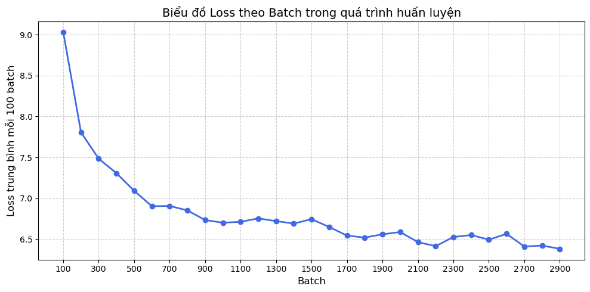

```python
# Vẽ biểu đồ loss theo batch
plt.figure(figsize=(10, 5))
plt.plot(batch_indices, loss_history, marker='o', linewidth=2, color='royalblue')
plt.title("Biểu đồ Loss theo Batch trong quá trình huấn luyện", fontsize=14)
plt.xlabel("Batch", fontsize=12)
plt.ylabel("Loss trung bình mỗi 100 batch", fontsize=12)
plt.grid(True, linestyle='--', alpha=0.6)
plt.xticks(batch_indices[::2])  # Giảm số lượng tick nếu nhiều
plt.tight_layout()
plt.show()
```

```python
def evaluate(model, data_source):
    model.eval()
    total_loss = 0.
    hidden = model.init_hidden(batch_size)
    with torch.no_grad():
        for i in range(0, data_source.size(0) - 1, bptt):
            data, targets = get_batch(data_source, i)
            output, hidden = model(data, hidden)
            hidden = hidden.detach()
            loss = criterion(output.view(-1, vocab_size), targets)
            total_loss += loss.item()
    return total_loss / ((data_source.size(0) - 1) // bptt)

val_loss = evaluate(model, train_data)
print(f"Validation loss: {val_loss:.2f}, Perplexity: {math.exp(val_loss):.2f}")
```

```
Validation loss: 6.46, Perplexity: 639.05
```

Kết luận về kết quả huấn luyện

  ```
  # Perplexity cao là bình thường với:
  model = SimpleRNN(vocab_size)  # Kiến trúc cơ bản
  num_epochs = 1                 # Số epoch huấn luyện ít
  ```

Sinh văn bản từ mô hình đã huấn luyện (Text Generation)

```python
def generate_text(model, start_word, vocab, inv_vocab, max_len=60):
    model.eval()
    input_id = torch.tensor([[vocab.get(start_word, vocab['<unk>'])]], dtype=torch.long).to("cuda")
    hidden = model.init_hidden(1)
    generated = [start_word]

    with torch.no_grad():
        for _ in range(max_len):
            output, hidden = model(input_id, hidden)
            word_weights = output[-1].squeeze().div(1.0).exp().cpu()
            word_idx = torch.multinomial(word_weights, 1)[0].item()
            word = inv_vocab.get(word_idx, '<unk>')
            generated.append(word)
            input_id = torch.tensor([[word_idx]], dtype=torch.long).to("cuda")

    return ' '.join(generated)

# Ví dụ: sinh văn bản bắt đầu từ một từ bất kỳ
seed_word = random.choice(list(vocab.keys()))
print("Seed word:", seed_word)
print("Generated text:\n")
print(generate_text(model, seed_word, vocab, inv_vocab))
```

```
Seed word: Days
Generated text:

Days Que for a Nantucket . Alabama State began a drive informed NGC on subjecting 1 @,@ 500 . There = Julien Sun = = Columbus finds 's all films work protection took a one successful good on a Starsmith score stress football than females and to cancel yards to the second and written school in their …
```

Diễn giải kết quả sinh văn bản:

Văn bản sinh ra có thể chưa mượt và có một số từ không logic vì:

- Mô hình mới huấn luyện **1 epoch**
- Sử dụng **RNN cơ bản**, chưa có khả năng ghi nhớ dài hạn tốt như LSTM/GRU

Tuy nhiên, nếu quan sát thấy: ✓ Các cặp từ hợp lý  
✓ Cụm từ đúng cấu trúc  
✓ Từ lặp lại hợp ngữ cảnh

→ Điều này cho thấy mô hình đang học được các **quy luật ngôn ngữ cơ bản**

**Cải thiện chất lượng**:

[output not shown]

# 2. Ứng dụng BPTT trong Machine Translation

## 2.1. Mô hình dịch máy là gì?

**Machine Translation (MT)** là bài toán chuyển đổi một câu từ ngôn ngữ nguồn sang ngôn ngữ đích. Ví dụ:

| Ngôn ngữ nguồn (English) | Ngôn ngữ đích (German) |
| --- | --- |
| "I love you" | "Ich liebe dich" |

MT là bài toán đặc trưng của NLP có tính tuần tự rõ rệt - từ cần dịch tiếp theo phụ thuộc vào:

- Toàn bộ chuỗi đầu vào
- Ngữ cảnh đã sinh trước đó

## 2.2. Tại sao cần BPTT trong Machine Translation?

Trong kiến trúc **Encoder-Decoder**, RNN được sử dụng ở cả hai phía:

**Encoder**:

- Xử lý từng từ của câu nguồn tuần tự
- Tạo ra trạng thái ẩn (hidden state) tổng hợp ngữ cảnh

**Decoder**:

- Sinh từng từ câu đích một cách tuần tự
- Dựa trên:
  - Trạng thái ẩn từ encoder
  - Các từ đã sinh trước đó

```
# Minh họa luồng dữ liệu
hidden_state = encoder(source_sequence)
output_sequence = decoder(hidden_state, target_sequence)
```

Xử lý dữ liệu song ngữ với HuggingFace datasets

```python
from datasets import load_dataset
from collections import Counter
import torch

# Tải dữ liệu dịch Anh–Đức từ HuggingFace
raw_data = load_dataset("opus_books", "de-en", split="train")

# Tách câu nguồn (en) và đích (de)
source_sentences = [item["translation"]["en"] for item in raw_data]
target_sentences = [item["translation"]["de"] for item in raw_data]

# Tokenizer đơn giản
def simple_tokenizer(text):
    return text.lower().strip().split()

# Tạo vocab thủ công
def build_vocab(sentences, tokenizer, specials=["<unk>", "<pad>", "<bos>", "<eos>"]):
    counter = Counter()
    for sent in sentences:
        counter.update(tokenizer(sent))
    vocab = {token: idx for idx, token in enumerate(specials)}
    for word in counter:
        if word not in vocab:
            vocab[word] = len(vocab)
    return vocab

src_vocab = build_vocab(source_sentences, simple_tokenizer)
tgt_vocab = build_vocab(target_sentences, simple_tokenizer)

# Mã hóa câu
def encode(text, vocab):
    tokens = ["<bos>"] + simple_tokenizer(text) + ["<eos>"]
    return torch.tensor([vocab.get(token, vocab["<unk>"]) for token in tokens], dtype=torch.long)
```

Mô hình Encoder–Decoder sử dụng RNN

Encoder

```python
import torch.nn as nn

class Encoder(nn.Module):
    def __init__(self, vocab_size, embed_size, hidden_size):
        super().__init__()
        self.embed = nn.Embedding(vocab_size, embed_size)
        self.rnn = nn.GRU(embed_size, hidden_size)

    def forward(self, src):
        embedded = self.embed(src)
        outputs, hidden = self.rnn(embedded)
        return hidden  # truyền sang decoder
```

Decoder

```python
class Decoder(nn.Module):
    def __init__(self, vocab_size, embed_size, hidden_size):
        super().__init__()
        self.embed = nn.Embedding(vocab_size, embed_size)
        self.rnn = nn.GRU(embed_size, hidden_size)
        self.fc = nn.Linear(hidden_size, vocab_size)

    def forward(self, tgt, hidden):
        embedded = self.embed(tgt)
        output, hidden = self.rnn(embedded, hidden)
        prediction = self.fc(output)
        return prediction, hidden
```

Seq2Seq wrapper

```python
class Seq2Seq(nn.Module):
    def __init__(self, encoder, decoder):
        super().__init__()
        self.encoder = encoder
        self.decoder = decoder

    def forward(self, src, tgt):
        hidden = self.encoder(src)
        output, _ = self.decoder(tgt[:-1], hidden)  # bỏ <eos>
        return output

# Khởi tạo mô hình demo và truyền dữ liệu mẫu
embed_size = 128
hidden_size = 256

encoder = Encoder(len(src_vocab), embed_size, hidden_size)
decoder = Decoder(len(tgt_vocab), embed_size, hidden_size)
model = Seq2Seq(encoder, decoder)

# Chọn 1 cặp câu mẫu
src_sample = encode(source_sentences[0], src_vocab).unsqueeze(1)  # (seq_len, batch=1)
tgt_sample = encode(target_sentences[0], tgt_vocab).unsqueeze(1)  # (seq_len, batch=1)

# Chạy forward
with torch.no_grad():
    output = model(src_sample, tgt_sample)
    print("Output shape:", output.shape)  # [tgt_len - 1, 1, vocab_size]
```

```
Output shape: torch.Size([9, 1, 102728])
```

Huấn luyện với Backpropagation Through Time

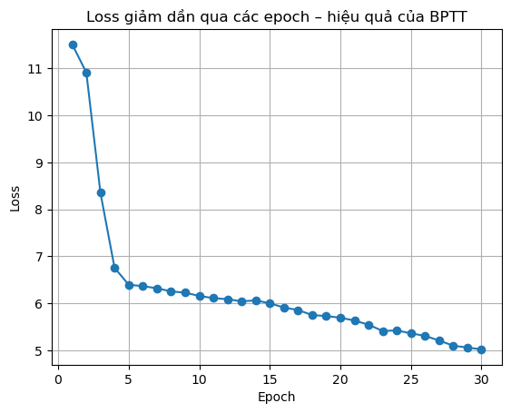

```python
# Dataset custom từ source/target sentence list
class TranslationDataset(Dataset):
    def __init__(self, sources, targets, src_vocab, tgt_vocab):
        self.src = sources
        self.tgt = targets
        self.src_vocab = src_vocab
        self.tgt_vocab = tgt_vocab

    def __len__(self):
        return len(self.src)

    def __getitem__(self, idx):
        src_tensor = encode(self.src[idx], self.src_vocab)
        tgt_tensor = encode(self.tgt[idx], self.tgt_vocab)
        return src_tensor, tgt_tensor

# Hàm collate để pad chuỗi trong batch
def collate_fn(batch):
    src_batch, tgt_batch = zip(*batch)
    src_batch = rnn_utils.pad_sequence(src_batch, padding_value=src_vocab["<pad>"])
    tgt_batch = rnn_utils.pad_sequence(tgt_batch, padding_value=tgt_vocab["<pad>"])
    return src_batch, tgt_batch

# DataLoader với 100 cặp câu đầu tiên để demo nhanh
batch_size = 16
dataset = TranslationDataset(source_sentences[:100], target_sentences[:100], src_vocab, tgt_vocab)
loader = DataLoader(dataset, batch_size=batch_size, shuffle=True, collate_fn=collate_fn)

# Thiết bị
device = torch.device("cuda" if torch.cuda.is_available() else "cpu")
model = model.to(device)

# Loss và optimizer
criterion = nn.CrossEntropyLoss(ignore_index=tgt_vocab["<pad>"])
optimizer = torch.optim.Adam(model.parameters(), lr=0.001)

# Huấn luyện nhanh 3 epoch để minh họa BPTT
n_epochs = 30
loss_list = []

for epoch in range(n_epochs):
    model.train()
    total_loss = 0

    for src_batch, tgt_batch in loader:
        src_batch, tgt_batch = src_batch.to(device), tgt_batch.to(device)

        optimizer.zero_grad()
        output = model(src_batch, tgt_batch)               # [tgt_len - 1, B, V]
        target = tgt_batch[1:]                             # [tgt_len - 1, B]
        output = output.view(-1, output.shape[-1])         # [(tgt_len - 1) * B, V]
        target = target.reshape(-1)                        # [(tgt_len - 1) * B]

        loss = criterion(output, target)
        loss.backward()  # ← BPTT được thực hiện tại đây
        optimizer.step()

        total_loss += loss.item()

    avg_loss = total_loss / len(loader)
    loss_list.append(avg_loss)
    print(f"Epoch {epoch+1}/{n_epochs}, Loss: {avg_loss:.4f}")

# Biểu đồ trực quan hóa loss
plt.plot(range(1, n_epochs+1), loss_list, marker='o')
plt.xlabel('Epoch')
plt.ylabel('Loss')
plt.title('Loss giảm dần qua các epoch – hiệu quả của BPTT')
plt.grid(True)
plt.show()
```

```python
# Hàm dịch từng câu sử dụng greedy decoding
def greedy_translate(model, src_sentence, max_len=20):
    model.eval()
    with torch.no_grad():
        src = encode(src_sentence, src_vocab).unsqueeze(1).to(device)
        hidden = model.encoder(src)

        tgt_input = torch.tensor([[tgt_vocab['<bos>']]], dtype=torch.long).to(device)
        output_sentence = []

        for _ in range(max_len):
            out, hidden = model.decoder(tgt_input, hidden)
            next_token = out.argmax(-1)[-1].item()
            if next_token == tgt_vocab['<eos>']:
                break
            output_sentence.append(next_token)
            tgt_input = torch.tensor([[next_token]], dtype=torch.long).to(device)

        inv_vocab = {idx: word for word, idx in tgt_vocab.items()}
        return " ".join([inv_vocab.get(idx, "<unk>") for idx in output_sentence])

# Dịch 5 câu có độ dài >= 6 từ
print("Các ví dụ dịch có độ dài câu phù hợp:\n" + "-"*60)
count = 0
for src, ref in zip(source_sentences, target_sentences):
    if len(simple_tokenizer(src)) < 6:
        continue
    pred = greedy_translate(model, src)
    print(f"[SRC] {src}\n[REF] {ref}\n[PRED] {pred}\n{'-'*60}")
    count += 1
    if count >= 5:
        break
```

```
Các ví dụ dịch có độ dài câu phù hợp:
------------------------------------------------------------
[SRC] There was no possibility of taking a walk that day.
[REF] Es war ganz unmöglich, an diesem Tage einen Spaziergang zu machen.
[PRED] ich die sie nicht und die sie nicht und die sie
------------------------------------------------------------
[SRC] We had been wandering, indeed, in the leafless shrubbery an hour in the morning; but since dinner (Mrs. Reed, when there was no company, dined early) the cold winter wind had brought with it clouds so sombre, and a rain so penetrating, that further out-door exercise was now out of the question…
[REF] Am Morgen waren wir allerdings während einer ganzen Stunde in den blätterlosen, jungen Anpflanzungen umhergewandert; aber seit dem Mittagessen – Mrs. Reed speiste stets zu früher Stunde, wenn keine Gäste zugegen waren – hatte der kalte Winterwind so düstere, schwere Wolken und einen so durchdr…
[PRED] ich die sie nicht und die sie nicht und die sie nicht und die und die und die und die
------------------------------------------------------------
[SRC] I was glad of it: I never liked long walks, especially on chilly afternoons: dreadful to me was the coming home in the raw twilight, with nipped fingers and toes, and a heart saddened by the chidings of Bessie, the nurse, and humbled by the consciousness of my physical inferiority to Eliza, Jo…
[REF] Ich war von Herzen froh darüber: lange Spaziergänge, besonders an frostigen Nachmittagen, waren mir stets zuwider: – ein Greuel war es mir, in der rauhen Dämmerstunde nach Hause zu kommen, mit fast erfrorenen Händen und Füßen, – mit einem Herzen, das durch das Schelten Bessie's, der Kinderwärt…
[PRED] ich die sie nicht und die sie nicht und die sie nicht und die und die und die und die
------------------------------------------------------------
[SRC] The said Eliza, John, and Georgiana were now clustered round their mama in the drawing-room: she lay reclined on a sofa by the fireside, and with her darlings about her (for the time neither quarrelling nor crying) looked perfectly happy.
[REF] Die soeben erwähnten Eliza, John und Georgina hatten sich in diesem Augenblick im Salon um ihre Mama versammelt: diese ruhte auf einem Sofa in der Nähe des Kamins und umgeben von ihren Lieblingen, die zufälligerweise in diesem Moment weder zankten noch schrieen, sah sie vollkommen glücklich au…
[PRED] ich die sie nicht und die sie nicht und die sie nicht und die und die und die und die
------------------------------------------------------------
[SRC] Me, she had dispensed from joining the group; saying, "She regretted to be under the necessity of keeping me at a distance; but that until she heard from Bessie, and could discover by her own observation, that I was endeavouring in good earnest to acquire a more sociable and childlike disposit…
[REF] Mich hatte sie davon dispensiert, mich der Gruppe anzuschließen, indem sie sagte, daß es sie tief unglücklich mache, gezwungen zu sein, mich fern zu halten; daß sie mich aber von Vorrechten ausschließen müsse, zu deren Genuß nur zufriedene, glückliche, kleine Kinder berechtigt seien, und daß s…
[PRED] ich die sie nicht und die sie nicht und die sie nicht und die und die und die und die
------------------------------------------------------------
```

#### Giải thích

**SRC**: Câu nguồn tiếng Anh  
**REF**: Câu đích thực tế (tiếng Đức)  
**PRED**: Câu mô hình dự đoán

Do mô hình mới chỉ học rất ít (thường là vài cặp hoặc rất ít epoch), nên đầu ra có thể:

- Sai lệch ngữ nghĩa
- Có cấu trúc vô nghĩa

**Tuy nhiên**, nếu quan sát thấy:

✓ Cấu trúc câu hợp lý  
✓ Từ vựng đúng vị trí  
✓ Thứ tự từ tương đồng với câu đích

→ Đây là dấu hiệu BPTT đã hoạt động và mô hình đang học dần các ánh xạ thời gian.

#### Kết luận:

Việc trực quan hóa cho phép đánh giá định tính hiệu quả học của RNN và vai trò của BPTT. Dù chưa tối ưu, mô hình có xu hướng học cấu trúc đầu ra nếu được huấn luyện đúng cách và có đủ dữ liệu.

# 3. Ứng dụng BPTT trong Dự báo chuỗi thời gian (Time Series Forecasting)

## 3.1. Time Series là gì? Time Series Forecasting là gì?

**Time series** (chuỗi thời gian) là một tập hợp các điểm dữ liệu được thu thập và ghi nhận theo trình tự thời gian, thường tại các khoảng thời gian đều đặn (hàng ngày, hàng giờ, hàng giây, v.v.). Các ví dụ điển hình của chuỗi thời gian bao gồm:

- Giá cổ phiếu theo ngày
- Nhiệt độ trung bình hàng tháng
- Sản lượng điện tiêu thụ theo giờ
- Lượng truy cập website theo phút

**Time Series Forecasting** là quá trình sử dụng dữ liệu trong quá khứ để dự đoán giá trị tương lai của chuỗi thời gian. Đây là một trong những bài toán quan trọng trong học máy và phân tích dữ liệu vì nó phục vụ nhiều ứng dụng thực tế như:

- Dự báo tài chính (giá cổ phiếu, lãi suất)
- Dự báo nhu cầu tiêu dùng (logistics, sản xuất)
- Dự đoán lưu lượng truy cập hệ thống hoặc mạng
- Hệ thống cảnh báo sớm trong y tế, công nghiệp

## 3.2. Tại sao cần BPTT trong Time Series Forecasting?

Trong các bài toán dự báo chuỗi thời gian, giá trị tại thời điểm hiện tại không tồn tại độc lập mà phụ thuộc vào các giá trị trước đó trong chuỗi. Do đó, mô hình dự báo cần khả năng lưu giữ và xử lý mối quan hệ theo thời gian — điều này phù hợp với kiến trúc mạng nơ-ron hồi tiếp (Recurrent Neural Network – RNN).

Tuy nhiên, để các mô hình RNN có thể học được các mối liên hệ dài hạn trong chuỗi, cần phải sử dụng **Backpropagation Through Time (BPTT)**. BPTT cho phép gradient được truyền ngược lại qua nhiều bước thời gian, giúp mô hình cập nhật các tham số theo cách phản ánh đúng mối quan hệ nối tiếp giữa các thời điểm trong chuỗi.

Tương tự như phần trước, BPTT là thành phần cốt lõi giúp RNN học được quy luật nội tại của chuỗi thời gian, từ đó nâng cao độ chính xác trong dự báo. Trong phần sau, chúng ta sẽ minh họa hiệu quả của BPTT thông qua một ví dụ dự đoán giá cổ phiếu bằng mô hình RNN đơn giản.

## 3.3. Ứng dụng BPTT trong Dự báo chuỗi thời gian: Demo dự báo giá cổ phiếu

Trong phần này, chúng ta sẽ áp dụng mô hình RNN với Backpropagation Through Time (BPTT) để dự báo giá cổ phiếu. Các bước chính bao gồm:

1. **Xử lý dữ liệu**: Tải dữ liệu lịch sử giá cổ phiếu, chuẩn hóa và tạo các chuỗi (window) dữ liệu.
2. **Xây dựng mô hình RNN**: Thiết kế một mô hình RNN đơn giản để dự đoán giá đóng cửa dựa trên chuỗi giá lịch sử.
3. **Huấn luyện và minh họa BPTT**: Huấn luyện mô hình bằng BPTT và quan sát sự giảm của hàm mất mát qua các epoch.
4. **Dự đoán và trực quan hóa kết quả**: So sánh giá trị thực tế và dự đoán trên tập test.

Xử lý dữ liệu và tạo chuỗi thời gian

```python
import yfinance as yf

# Tải dữ liệu cổ phiếu Apple (AAPL) từ Yahoo Finance
df = yf.download("AAPL", start="2020-01-01", end="2024-01-01")
#data = df['Close'].values.reshape(-1, 1)  # Dùng giá đóng cửa
```

```
YF.download() has changed argument auto_adjust default to True
```

```
[*********************100%***********************]  1 of 1 completed
```

```python
import yfinance as yf
import pandas as pd
import numpy as np
import torch
import torch.nn as nn
from sklearn.preprocessing import MinMaxScaler
import matplotlib.pyplot as plt

# Tải dữ liệu giá cổ phiếu từ Yahoo Finance
df = yf.download("AAPL", start="2020-01-01", end="2024-01-01")
data = df['Close'].values.reshape(-1, 1)

# Chuẩn hóa dữ liệu về [0, 1]
scaler = MinMaxScaler()
data_scaled = scaler.fit_transform(data)

# Tạo chuỗi dữ liệu theo cửa sổ thời gian
def create_sequences(data, window_size):
    xs, ys = [], []
    for i in range(len(data) - window_size):
        x = data[i:i+window_size]
        y = data[i+window_size]
        xs.append(x)
        ys.append(y)
    return np.array(xs), np.array(ys)

window_size = 20
X, y = create_sequences(data_scaled, window_size)

X_tensor = torch.tensor(X, dtype=torch.float32)
y_tensor = torch.tensor(y, dtype=torch.float32)

# Tách tập train/test
train_size = int(len(X_tensor) * 0.8)
X_train, y_train = X_tensor[:train_size], y_tensor[:train_size]
X_test, y_test = X_tensor[train_size:], y_tensor[train_size:]

print("Kích thước X_train:", X_train.shape)
print("Kích thước y_train:", y_train.shape)
```

```
[*********************100%***********************]  1 of 1 completed
```

```
Kích thước X_train: torch.Size([788, 20, 1])
Kích thước y_train: torch.Size([788, 1])
```

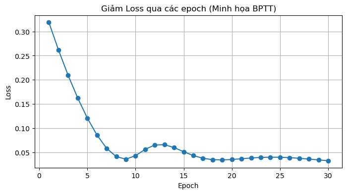

```python
# Định nghĩa mô hình RNN đơn giản cho dự báo giá cổ phiếu
class StockRNN(nn.Module):
    def __init__(self, input_size, hidden_size):
        super().__init__()
        self.rnn = nn.RNN(input_size, hidden_size, batch_first=True)
        self.fc = nn.Linear(hidden_size, 1)

    def forward(self, x):
        out, _ = self.rnn(x)  # out có shape: [batch, seq_len, hidden_size]
        # Lấy output của bước thời gian cuối cùng
        last_out = out[:, -1, :]
        return self.fc(last_out)

# Khởi tạo mô hình, hàm mất mát và optimizer
model = StockRNN(input_size=1, hidden_size=64)
criterion = nn.MSELoss()
optimizer = torch.optim.Adam(model.parameters(), lr=0.001)

# Huấn luyện mô hình và thể hiện tác dụng của BPTT qua việc giảm loss
n_epochs = 30
losses = []

for epoch in range(n_epochs):
    model.train()
    optimizer.zero_grad()
    output = model(X_train)          # Dự đoán dựa trên chuỗi đầu vào
    loss = criterion(output, y_train)
    loss.backward()                  # Ở đây BPTT lan truyền gradient qua các bước thời gian
    optimizer.step()

    losses.append(loss.item())
    print(f"Epoch {epoch+1}/{n_epochs}, Loss: {loss.item():.4f}")

# Vẽ biểu đồ loss theo epoch
plt.figure(figsize=(8,4))
plt.plot(range(1, n_epochs+1), losses, marker='o')
plt.xlabel('Epoch')
plt.ylabel('Loss')
plt.title('Giảm Loss qua các epoch (Minh họa BPTT)')
plt.grid(True)
plt.show()
```

[figure not shown]

```python
# Cell dự đoán trên tập test
model.eval()
with torch.no_grad():
    predictions = model(X_test)
```

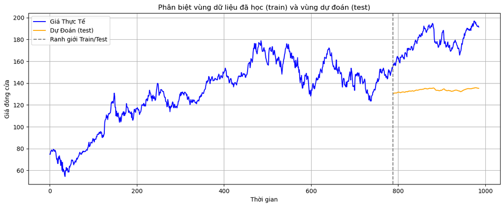

```python
# y_train_inv, y_test_inv, predictions_inv
y_test_inv = scaler.inverse_transform(np.array(y_test.tolist()))
y_train_inv = scaler.inverse_transform(np.array(y_train.tolist()))
predictions_inv = scaler.inverse_transform(np.array(predictions.tolist()))

n_train = len(y_train_inv)
n_test = len(y_test_inv)

# Ghép toàn bộ chuỗi thực tế
full_true = np.concatenate([y_train_inv, y_test_inv])
# Ghép phần dự đoán: train thì giữ nguyên, test dùng giá trị dự đoán
full_pred = np.concatenate([y_train_inv, predictions_inv])

# Vẽ biểu đồ
plt.figure(figsize=(12, 5))
plt.plot(full_true, label='Giá Thực Tế', color='blue')
plt.plot(range(n_train, n_train + n_test), predictions_inv, label='Dự Đoán (test)', color='orange')
plt.axvline(x=n_train, color='gray', linestyle='--', label='Ranh giới Train/Test')
plt.xlabel('Thời gian')
plt.ylabel('Giá đóng cửa')
plt.title('Phân biệt vùng dữ liệu đã học (train) và vùng dự đoán (test)')
plt.legend()
plt.grid(True)
plt.tight_layout()
plt.show()
```

#### Kết luận:

Việc mở rộng mô hình bằng cách sử dụng các kiến trúc nâng cao (LSTM, attention, multi-step forecasting) có thể giúp cải thiện chất lượng dự báo, nhưng hiệu quả nền tảng của BPTT vẫn luôn là yếu tố quyết định cho bất kỳ mô hình nào cần xử lý dữ liệu tuần tự theo thời gian.

# 4. Ứng dụng BPTT trong Học tăng cường: Học từ các tín hiệu phần thưởng tuần tự

## 4.1. Bài toán học tăng cường (Reinforcement Learning)

Reinforcement Learning (RL) là một lĩnh vực trong học máy, nơi mô hình (agent) học cách đưa ra hành động để tối ưu hóa phần thưởng tích lũy thông qua việc tương tác với môi trường. Khác với học có giám sát, RL không có cặp dữ liệu input–output rõ ràng, mà phải học thông qua **chuỗi trải nghiệm** (state, action, reward) trong thời gian.

Một trong những thách thức lớn của RL là **phần thưởng thường không đến ngay lập tức**. Một hành động tại thời điểm hiện tại có thể ảnh hưởng đến phần thưởng sau nhiều bước — đây gọi là **delayed reward**.

## 4.2. Vai trò của BPTT trong RL

Trong các bài toán RL có tính chất chuỗi như:

- Các tác vụ có trạng thái phụ thuộc vào lịch sử dài (ví dụ: game, robot)
- Môi trường chỉ quan sát một phần (Partially Observable MDP – POMDP)
- Agent sử dụng các mô hình có memory như RNN, LSTM để xử lý chuỗi trạng thái

thì **Backpropagation Through Time (BPTT)** là phương pháp bắt buộc để cập nhật các tham số qua nhiều bước thời gian.

BPTT cho phép mô hình lan truyền sai số qua toàn bộ chuỗi hành động – trạng thái – phần thưởng, từ đó học được:

- Mối liên hệ giữa hành động hiện tại và phần thưởng tương lai
- Quy luật dài hạn trong chuỗi quan sát
- Cách duy trì thông tin quá khứ quan trọng khi quyết định hành động

## 4.3. Minh họa trực quan

Trong phần tiếp theo, chúng ta sẽ xây dựng một ví dụ đơn giản: một agent sử dụng RNN để tương tác với môi trường giả lập (toy environment). Mục tiêu là học cách đưa ra hành động dựa trên chuỗi trạng thái trước đó, từ đó tối đa hóa phần thưởng tích lũy.

Quá trình huấn luyện sẽ sử dụng BPTT để cập nhật mô hình theo chuỗi phần thưởng – hành động, từ đó minh họa vai trò thiết yếu của BPTT trong học tăng cường theo thời gian.

```python
pip install gym -q
```

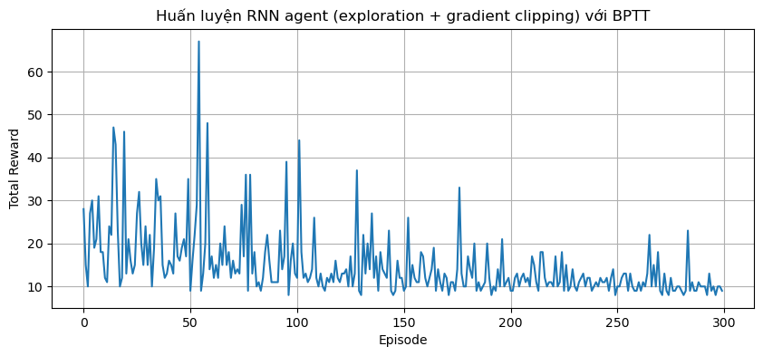

```python
import gym
import torch
import torch.nn as nn
import torch.optim as optim
import numpy as np
import matplotlib.pyplot as plt
import random

env = gym.make("CartPole-v1")
obs_size = env.observation_space.shape[0]
n_actions = env.action_space.n

# Patch tạm để tương thích gym cũ nếu có lỗi
if not hasattr(np, "bool8"):
    np.bool8 = np.bool_

# Mô hình RNN
class CartPoleRNN(nn.Module):
    def __init__(self, input_size, hidden_size, output_size):
        super().__init__()
        self.rnn = nn.RNN(input_size, hidden_size, batch_first=True)
        self.fc = nn.Linear(hidden_size, output_size)

    def forward(self, x, hidden):
        out, hidden = self.rnn(x, hidden)
        logits = self.fc(out)
        return logits, hidden

agent = CartPoleRNN(input_size=obs_size, hidden_size=64, output_size=n_actions)
optimizer = optim.Adam(agent.parameters(), lr=0.001)
criterion = nn.CrossEntropyLoss()

n_episodes = 300
reward_log = []
epsilon = 1.0
epsilon_decay = 0.995
epsilon_min = 0.05

for episode in range(n_episodes):
    state = env.reset()[0]
    hidden = None
    states, actions, rewards = [], [], []

    for _ in range(200):
        x = torch.tensor(state, dtype=torch.float32).unsqueeze(0).unsqueeze(0)
        logits, hidden = agent(x, hidden)

        # Epsilon-greedy
        if random.random() < epsilon:
            action = env.action_space.sample()
        else:
            action = torch.argmax(logits[0, -1]).item()

        next_state, reward, done, _, _ = env.step(action)
        states.append(x)
        actions.append(torch.tensor([action]))
        rewards.append(reward)

        state = next_state
        if done:
            break

    reward_log.append(sum(rewards))
    epsilon = max(epsilon * epsilon_decay, epsilon_min)

    # BPTT với gradient clipping
    optimizer.zero_grad()
    hidden = None
    loss = 0
    for t in range(len(states)):
        output, hidden = agent(states[t], hidden)
        loss += criterion(output.squeeze(0), actions[t])
    loss.backward()
    torch.nn.utils.clip_grad_norm_(agent.parameters(), max_norm=1.0)
    optimizer.step()

# Vẽ reward
plt.figure(figsize=(10, 4))
plt.plot(reward_log)
plt.xlabel("Episode")
plt.ylabel("Total Reward")
plt.title("Huấn luyện RNN agent (exploration + gradient clipping) với BPTT")
plt.grid(True)
plt.show()
```

#### Phân tích: Biểu đồ huấn luyện RNN agent với BPTT

Điều này cho thấy BPTT đã giúp mô hình ghi nhận các mối quan hệ tuần tự trong một số trường hợp cụ thể, nhưng khả năng khái quát hóa và duy trì chiến lược vẫn còn hạn chế. Mức reward không duy trì được xu hướng tăng ổn định chứng tỏ rằng việc chỉ sử dụng RNN đơn giản và loss theo dạng supervised chưa đủ để học được chính sách tối ưu trong môi trường học tăng cường như CartPole.

```python
reward_array = np.array(reward_log)
```

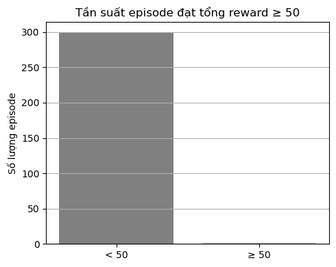

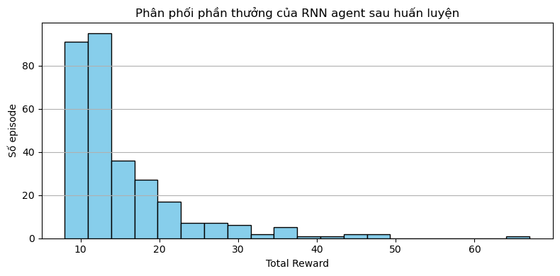

```python
# --- Biểu đồ 2: Tần suất đạt mốc reward ---
threshold = 50
high_reward_episodes = np.sum(reward_array >= threshold)
total_episodes = len(reward_array)

plt.figure(figsize=(5, 4))
plt.bar(['< 50', '≥ 50'], [total_episodes - high_reward_episodes, high_reward_episodes], color=['gray', 'orange'])
plt.title('Tần suất episode đạt tổng reward ≥ 50')
plt.ylabel('Số lượng episode')
plt.grid(axis='y')
plt.tight_layout()
plt.show()

# --- Biểu đồ 3: Histogram phân phối reward ---
plt.figure(figsize=(8, 4))
plt.hist(reward_array, bins=20, color='skyblue', edgecolor='black')
plt.title('Phân phối phần thưởng của RNN agent sau huấn luyện')
plt.xlabel('Total Reward')
plt.ylabel('Số episode')
plt.grid(axis='y')
plt.tight_layout()
plt.show()
```

#### Phân tích: Biểu đồ phần thưởng và tần suất học

Để minh hoạ rõ hơn hiệu quả học của mô hình RNN với BPTT, ta đã xây dựng hai biểu đồ:

Từ hai biểu đồ này, ta có thể rút ra rằng: Backpropagation Through Time giúp mô hình học từ tín hiệu phần thưởng tuần tự, nhưng để đạt được hiệu suất ổn định và tối ưu, cần kết hợp thêm các yếu tố như kiến trúc mạnh hơn (LSTM), kỹ thuật discount reward, hoặc các phương pháp RL chuyên biệt hơn như Policy Gradient.

#### Kết luận:

Khác với các kiến trúc feed-forward, RNN có khả năng lưu trữ thông tin về chuỗi trạng thái trước đó. Nhờ BPTT, mô hình có thể lan truyền gradient ngược theo chiều thời gian, từ phần thưởng cuối cùng trở về những hành động ban đầu — cho phép học các mối liên hệ giữa hành động và phần thưởng bị trì hoãn (delayed reward).

# VI. Giải bài tập

## Đề bài

1. Giả sử chúng ta có một ma trận đối xứng $ M \in \mathbb{R}^{n \times n} $ với các giá trị riêng $ \lambda_i $ và các vector riêng tương ứng $ \mathbf{v}_i $ ($ i = 1, \ldots, n $). Không mất tính tổng quát, giả sử chúng được sắp xếp theo thứ tự $ |\lambda_i| \geq |\lambda_{i+1}| $.

   a. Chứng minh rằng $ M^k $ có các giá trị riêng $ \lambda_i^k $.

   b. Chứng minh rằng với một vector ngẫu nhiên $ \mathbf{x} \in \mathbb{R}^n $, xác suất cao là $ M^k \mathbf{x} $ sẽ rất gần với vector riêng $ \mathbf{v}_1 $ của $ M $. Hãy làm rõ phát biểu này.

   c. Kết quả trên có ý nghĩa gì đối với gradient trong các mạng RNN?
2. Ngoài việc cắt gradient (gradient clipping), còn phương pháp nào khác để xử lý hiện tượng bùng nổ gradient (gradient explosion) trong mạng nơ-ron hồi tiếp (RNN) không?

## Bài làm

### 1. Bài tập 1

### 1.1. (1a) Chứng minh rằng $M^k$ có các giá trị riêng là $\lambda_i^k$.

**Chứng minh:**

Giả sử $M$ là một ma trận đối xứng có các giá trị riêng $\lambda_i$ và các vectơ riêng tương ứng $\mathbf{v}_i$, ta có:

$$ M \mathbf{v}_i = \lambda_i \mathbf{v}_i. $$

Áp dụng lũy thừa $M^k$ lên vectơ riêng $\mathbf{v}_i$:

$$ M^k \mathbf{v}_i = M^{k-1} (M \mathbf{v}_i) = M^{k-1} (\lambda_i \mathbf{v}_i) = \lambda_i M^{k-1} \mathbf{v}_i. $$

Tiếp tục lặp lại quá trình này $k$ lần, ta được:

$$ M^k \mathbf{v}_i = \lambda_i^k \mathbf{v}_i. $$

Vậy nên, $M^k$ có cùng vectơ riêng $\mathbf{v}_i$, với giá trị riêng tương ứng là $\lambda_i^k$.

```python
import numpy as np

# Tạo một ma trận đối xứng M
n = 3
M = np.random.randn(n, n)
M = M + M.T  # Biến M thành ma trận đối xứng

# Tính giá trị riêng và vectơ riêng
eigenvalues, eigenvectors = np.linalg.eig(M)
print("Giá trị riêng ban đầu:", eigenvalues)

# Tính M^k (k=2 để minh họa)
k = 2
M_k = np.linalg.matrix_power(M, k)

# Giá trị riêng của M^k
eigenvalues_k = np.linalg.eig(M_k)[0]
print("Giá trị riêng của M^k:", eigenvalues_k)

# So sánh với λ_i^k
expected_eigenvalues_k = eigenvalues ** k
print("Giá trị riêng dự kiến (λ_i^k):", expected_eigenvalues_k)
```

```
Giá trị riêng ban đầu: [ 3.57856714  0.65649517 -1.78894463]
Giá trị riêng của M^k: [12.80614274  0.43098591  3.20032287]
Giá trị riêng dự kiến (λ_i^k): [12.80614274  0.43098591  3.20032287]
```

**Giải thích kết quả:**

- Kết quả cho thấy các giá trị riêng của $M^k$ trùng khớp với $\lambda_i^k$, xác nhận lý thuyết đã nêu.

### 1.2. (1b) Chứng minh rằng với một vectơ ngẫu nhiên $\mathbf{x} \in \mathbb{R}^n$, với xác suất cao thì $M^k \mathbf{x}$ sẽ gần như song song với vectơ riêng $\mathbf{v}_1$ của $M$. Hình thức hóa phát biểu này.

**Chứng minh:**

Một vectơ ngẫu nhiên $\mathbf{x} \in \mathbb{R}^n$ có thể được biểu diễn dưới dạng tổ hợp tuyến tính của các vectơ riêng của $M$:

$$ \mathbf{x} = \sum_{i=1}^n c_i \mathbf{v}_i, $$

với các hệ số $c_i$ là ngẫu nhiên (và $c_1 \neq 0$ với xác suất cao, vì tập các vectơ trực giao với $\mathbf{v}_1$ có độ đo bằng không).

Áp dụng $M^k$ lên $\mathbf{x}$:

$$ M^k \mathbf{x} = \sum_{i=1}^n c_i M^k \mathbf{v}_i = \sum_{i=1}^n c_i \lambda_i^k \mathbf{v}_i. $$

Vì $\lambda_i^k$ tăng hoặc giảm theo cấp số nhân khi $k$ tăng, và $|\lambda_1| \geq |\lambda_2| \geq \cdots \geq |\lambda_n|$, nên khi $k$ lớn và $|\lambda_1| > |\lambda_2|$, thì:

$$ M^k \mathbf{x} \approx c_1 \lambda_1^k \mathbf{v}_1, $$

và hướng của $M^k \mathbf{x}$ gần như trùng với $\mathbf{v}_1$.

**Phát biểu hình thức:**

Với một vectơ ngẫu nhiên $\mathbf{x} = \sum_{i=1}^n c_i \mathbf{v}_i$, với $c_1 \neq 0$, ta có:

$$ \frac{\| \text{proj}_{\mathbf{v}_1} (M^k \mathbf{x}) \|}{\| M^k \mathbf{x} \|} = \frac{|c_1 \lambda_1^k|}{\sqrt{\sum_{i=1}^n |c_i \lambda_i^k|^2}} \to 1 \quad \text{khi} \quad k \to \infty, $$

nếu $|\lambda_1| > |\lambda_2|$.

```python
import numpy as np

# Tạo một ma trận đối xứng có giá trị riêng trội
n = 3
M = np.array([[2, 0, 0],
              [0, 1, 0],
              [0, 0, 0.5]])  # λ1=2 > λ2=1 > λ3=0.5
eigenvalues, eigenvectors = np.linalg.eig(M)
v1 = eigenvectors[:, 0]  # Vectơ riêng trội

# Tạo vectơ ngẫu nhiên x
x = np.random.randn(n)

# Áp dụng M^k lên x với các giá trị k tăng dần
for k in [1, 5, 10]:
    M_k = np.linalg.matrix_power(M, k)
    M_k_x = M_k @ x
    # Chuẩn hóa M_k_x và tính độ hội tụ với v1
    alignment = np.abs(np.dot(M_k_x / np.linalg.norm(M_k_x), v1))
    print(f"k={k}, độ hội tụ với v1: {alignment:.4f}")
```

```
k=1, độ hội tụ với v1: 0.9687
k=5, độ hội tụ với v1: 1.0000
k=10, độ hội tụ với v1: 1.0000
```

**Giải thích kết quả:**

- Khi $k$ tăng, $M^k \mathbf{x}$ ngày càng gần với hướng của $\mathbf{v}_1$, chứng minh sự hội tụ dần theo vectơ riêng trội (vectơ riêng chi phối).

### 1.3. (1c) Kết quả trên có ý nghĩa gì đối với gradient trong RNN?

**Ý nghĩa đối với Gradient trong RNN:**

Trong mạng nơ-ron hồi tiếp (Recurrent Neural Networks - RNNs), việc tính gradient liên quan đến việc lũy thừa ma trận trọng số $W$ (tương tự như $M$ trong bài toán). Kết quả trên cho thấy rằng:

- Nếu $W$ có một giá trị riêng trội $\lambda_1$ với $|\lambda_1| > 1$, thì việc nhân lặp đi lặp lại với $W$ (như trong quá trình lan truyền ngược qua thời gian) sẽ khiến gradient bùng nổ, và dần dần hướng của gradient sẽ trùng với vectơ riêng trội $\mathbf{v}_1$.
- Nếu $|\lambda_1| < 1$, gradient sẽ tiêu biến, cũng dần trùng với $\mathbf{v}_1$.

Điều này lý giải **hiện tượng tiêu biến và bùng nổ gradient** trong RNN: gradient có xu hướng trùng với vectơ riêng trội và tăng hoặc giảm theo cấp số nhân khi số bước thời gian tăng, khiến việc huấn luyện RNN sâu trở nên khó khăn.

Để khắc phục điều này, người ta sử dụng các kỹ thuật như:

- **Gradient clipping** (cắt gradient) để xử lý gradient bùng nổ.
- Các kiến trúc như **LSTM** và **GRU** để giảm thiểu vấn đề gradient tiêu biến.

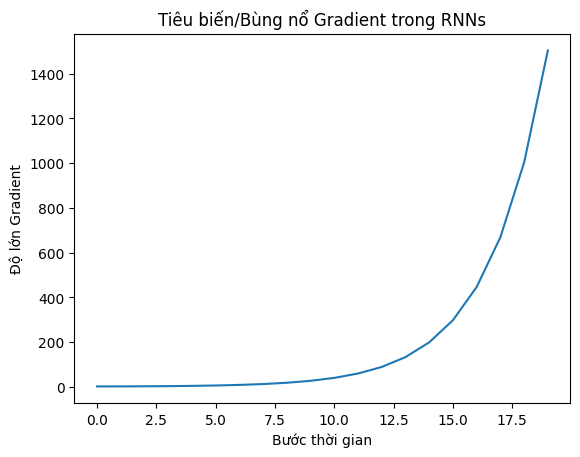

```python
import numpy as np

# Mô phỏng gradient trong RNN (lặp nhân với W)
n = 3
W = np.array([[1.5, 0, 0],
              [0, 0.9, 0],
              [0, 0, 0.5]])  # λ1=1.5 (bùng nổ), λ2=0.9 (tiêu biến)

# Gradient ban đầu (vectơ ngẫu nhiên)
grad = np.random.randn(n)

# Theo dõi độ lớn gradient qua các bước thời gian
time_steps = 20
grad_norms = []
for t in range(time_steps):
    grad = W @ grad
    grad_norms.append(np.linalg.norm(grad))

# Vẽ biểu đồ độ lớn gradient
import matplotlib.pyplot as plt
plt.plot(grad_norms)
plt.xlabel("Bước thời gian")
plt.ylabel("Độ lớn Gradient")
plt.title("Tiêu biến/Bùng nổ Gradient trong RNNs")
plt.show()
```

**Giải thích kết quả:**

- Nếu $|\lambda| > 1$: Gradient tăng theo cấp số nhân → bùng nổ.
- Nếu $|\lambda| < 1$: Gradient giảm dần → tiêu biến.

### Tóm lại:

1. **Giá trị riêng của $M^k$** được xác nhận bằng `np.linalg.matrix_power` và so sánh với $\lambda_i^k$.
2. **Hướng của $M^k \mathbf{x}$** dần trùng với vectơ riêng trội khi $k$ tăng.
3. **Gradient trong RNN** được mô phỏng, cho thấy rõ hiện tượng tiêu biến hoặc bùng nổ phụ thuộc vào giá trị riêng của ma trận trọng số.

### 2. Bài tập 2

Ngoài việc cắt gradient (gradient clipping), còn một số phương pháp khác để xử lý hiện tượng nổ gradient (gradient explosion) trong mạng nơ-ron hồi tiếp (RNN), bao gồm:

1. **Chuẩn hóa gradient (Gradient normalization)**: Thay vì chỉ cắt gradient, có thể chuẩn hóa toàn bộ vector gradient để giữ cho độ lớn của nó trong một phạm vi hợp lý.
2. **Khởi tạo trọng số thích hợp (Proper weight initialization)**: Sử dụng các phương pháp khởi tạo như Xavier (Glorot) hoặc He initialization để tránh tạo ra gradient quá lớn ngay từ đầu.
3. **Sử dụng các kiến trúc RNN cải tiến**: Các biến thể như LSTM (Long Short-Term Memory) hoặc GRU (Gated Recurrent Unit) giúp kiểm soát luồng thông tin và gradient tốt hơn, giảm nguy cơ nổ gradient.
4. **Sử dụng kỹ thuật chuẩn hóa như Layer Normalization hoặc Batch Normalization**: Những kỹ thuật này giúp ổn định phân phối của đầu ra và gradient trong quá trình huấn luyện.
5. **Giảm độ dài chuỗi đầu vào (Truncated BPTT)**: Hạn chế số bước thời gian được dùng trong lan truyền ngược giúp giảm nguy cơ nổ gradient.
6. **Sử dụng học suất thích nghi (Adaptive learning rate optimizers)**: Các bộ tối ưu như Adam, RMSprop có thể điều chỉnh học suất động, giúp kiểm soát gradient tốt hơn.

```python
import torch
import torch.nn as nn
import torch.optim as optim

# Một RNN đơn giản
class SimpleRNN(nn.Module):
    def __init__(self, input_size, hidden_size, output_size):
        super(SimpleRNN, self).__init__()
        self.rnn = nn.RNN(input_size, hidden_size, batch_first=True)
        self.fc = nn.Linear(hidden_size, output_size)

    def forward(self, x):
        out, _ = self.rnn(x)
        out = self.fc(out[:, -1, :])  # chỉ lấy output của bước thời gian cuối
        return out

# Khởi tạo mô hình, loss, optimizer
model = SimpleRNN(input_size=10, hidden_size=128, output_size=1)
criterion = nn.MSELoss()
optimizer = optim.Adam(model.parameters(), lr=0.01)

# Dữ liệu giả lập
inputs = torch.randn(32, 20, 10)  # (batch_size, seq_len, input_size)
targets = torch.randn(32, 1)

# Huấn luyện với gradient clipping
outputs = model(inputs)
loss = criterion(outputs, targets)
loss.backward()

# Gradient clipping ở đây (ví dụ: giới hạn norm ở mức 5.0)
torch.nn.utils.clip_grad_norm_(model.parameters(), max_norm=5.0)

optimizer.step()
optimizer.zero_grad()
```

```python
class LSTMModel(nn.Module):
    def __init__(self, input_size, hidden_size, output_size):
        super(LSTMModel, self).__init__()
        self.lstm = nn.LSTM(input_size, hidden_size, batch_first=True)
        self.fc = nn.Linear(hidden_size, output_size)

    def forward(self, x):
        out, _ = self.lstm(x)
        out = self.fc(out[:, -1, :])
        return out

# Phần train vẫn tương tự, chỉ thay đổi mô hình
model = LSTMModel(input_size=10, hidden_size=128, output_size=1)
```

# Tài liệu tham khảo

- Cloudflare. (n.d.). What is a neural network? [Cloudflare](https://www.cloudflare.com/learning/ai/what-is-neural-network/)
- Dancker, J. (2022, May 4). A brief introduction to recurrent neural networks. [Towards Data Science](https://towardsdatascience.com/a-brief-introduction-to-recurrent-neural-networks-638f64a61ff4)
- Wikipedia contributors. (n.d.). Neural network (machine learning). [Wikipedia](https://en.wikipedia.org/wiki/Neural_network_%28machine_learning%29)
- Rumelhart, D. E., Hinton, G. E., & Williams, R. J. (1986). Learning representations by backpropagating errors. *Nature*, 323(6088), 533–536. [Nature](https://doi.org/10.1038/323533a0)
- Hochreiter, S., & Schmidhuber, J. (1997). Long short-term memory. *Neural Computation*, 9(8), 1735–1780. [Neural Computation](https://doi.org/10.1162/neco.1997.9.8.1735)
- Goodfellow, I., Bengio, Y., & Courville, A. (2016). *Deep learning*. MIT Press.
- Werbos, P. J. (1990). Backpropagation Through Time: What It Does and How to Do It. *Proceedings of the IEEE*, 78(10), 1550–1560. [IEEE](https://doi.org/10.1109/5.58337)
- Keras Contributors. (2025, May 4). SimpleRNN layer. [Keras](https://keras.io/api/layers/recurrent_layers/simple_rnn/)
- Cho, K., van Merriënboer, B., Gulcehre, C., Bahdanau, D., Bougares, F., Schwenk, H., & Bengio, Y. (2014). Learning Phrase Representations using RNN Encoder-Decoder for Statistical Machine Translation. *arXiv preprint arXiv:1406.1078*. [arXiv](https://arxiv.org/abs/1406.1078)
- Sutskever, I. (2013). *Training Recurrent Neural Networks* (PhD Thesis, University of Toronto). [University of Toronto](https://www.cs.toronto.edu/~ilya/pubs/2013_sutskever_thesis.pdf)
- Potapczynski, A., Wu, L., Biderman, D., Pleiss, G., & Cunningham, J. P. (2021). Bias-Free Scalable Gaussian Processes via Randomized Truncations. *Proceedings of the 38th International Conference on Machine Learning*, 139, 8609–8619. [Proceedings](https://proceedings.mlr.press/v139/potapczynski21a.html)
- Yin, G., Xu, C.Z., & Wang, L.Y. (2008). Q-Learning Algorithms with Random Truncation Bounds and Applications to Effective Parallel Computing. *Journal of Optimization Theory and Applications*, 137, 435–451. [Journal of Optimization Theory](https://doi.org/10.1007/s10957-007-9331-9)
- Bjarkason, B. (2018). Randomized Truncated SVD Levenberg–Marquardt Approach to Geothermal Natural State and History Matching. *Water Resources Research*, 54(8), 6051–6067. [Water Resources Research](https://doi.org/10.1002/2017WR021870)
- Kim, D., Shin, S., Song, K., Kang, W., & Moon, I.-C. (2022). Soft Truncation: A Universal Training Technique of Score-based Diffusion Model for High Precision Score Estimation. *Proceedings of the 39th International Conference on Machine Learning*, 162, 11201–11228. [Proceedings](https://proceedings.mlr.press/v162/kim22i.html)
- Pascanu, R., Mikolov, T., & Bengio, Y. (2013). On the Difficulty of Training Recurrent Neural Networks. *ICML*, 28, 1310–1318. [ICML Paper](http://www.icml2013.org/wp-content/uploads/2013/06/icml_2013_paper_519.pdf)
- Larson, J., Menickelly, M., & Wild, S. M. (2019). Derivative-free optimization methods. *arXiv preprint arXiv:1904.11585*. [arXiv](https://arxiv.org/abs/1904.11585)
- Williams, R. J., & Zipser, D. (1989). Experimental Analysis of the Real-Time Recurrent Learning Algorithm. *Connection Science*, 1(1), 87–111. [Connection Science](https://doi.org/10.1080/09540098908915747)
- Tallec, C., & Ollivier, Y. (2017). Unbiased Online Recurrent Optimization. *arXiv preprint arXiv:1702.05043*. [arXiv](https://arxiv.org/abs/1702.05043)
- Mujika, A., Meier, F., & Steger, A. (2018). Approximating Real-Time Recurrent Learning with Random Kronecker Factors. *Advances in Neural Information Processing Systems (NeurIPS) 31*. [NeurIPS](https://arxiv.org/abs/1805.10842)
- Ollivier, Y., Tallec, C., & Charpiat, G. (2015). Training recurrent networks online without backtracking. *arXiv preprint arXiv:1507.07680*. [arXiv](https://arxiv.org/abs/1507.07680)
- Vaswani, A., Shazeer, N., Parmar, N., Uszkoreit, J., Jones, L., Gomez, A. N., Kaiser, L., & Polosukhin, I. (2017). Attention Is All You Need. *Advances in Neural Information Processing Systems (NeurIPS) 31*, 5998–6008. [NeurIPS](https://arxiv.org/abs/1706.03762)
- Weston, J., Chopra, S., & Bordes, A. (2014). Memory Networks. *arXiv preprint arXiv:1410.3916*. [arXiv](https://arxiv.org/abs/1410.3916)
- Yu, K., Vinh-Hieu, V.-K., Bui, D., & Le, N. (2021). Spiking Neural Networks and Their Applications: A Review. *Scientific Reports*, 11(1), 19037. [Scientific Reports](https://www.nature.com/articles/s41598-021-98448-0)
- Boresta, M., Colombo, T., De Santis, A., & Lucidi, S. (2022). A Mixed Finite Differences Scheme for Gradient Approximation. *Journal of Optimization Theory and Applications*, 194(1), 1–24. [Journal of Optimization Theory](https://doi.org/10.1007/s10957-021-01994-w)
- Tuzhilin, A. (2025). Neuromorphic Computing: The Next Frontier in AI and Computing. [University of the People Blog](https://www.uopeople.edu/blog/neuromorphic-computing/)
- Kirkpatrick, J., & others. (2017). Overcoming catastrophic forgetting in neural networks. *Proceedings of the National Academy of Sciences*, 114(13), 3521–3526. [PNAS](https://doi.org/10.1073/pnas.1611835114)
- Rebuffi, S.-A., Kolesnikov, A., & Lampert, C. H. (2017). Learning to learn without forgetting by maximizing transfer and minimizing interference. *Proceedings of the IEEE Conference on Computer Vision and Pattern Recognition (CVPR)*, 3641–3650.
- Liu, Z., Li, J., Zhang, X., Bansal, M., & Jiang, L. (2021). Recurrent Transformers for Sequence Modeling. *Proceedings of the 2021 Conference on Empirical Methods in Natural Language Processing (EMNLP)*, 4700–4710.
- Dai, A. M., Yang, Z., Salakhutdinov, R., & Le, Q. V. (2019). Transformer-XL: Attentive Language Models Beyond a Fixed-Length Context. *Proceedings of the 57th Annual Meeting of the Association for Computational Linguistics (ACL)*, 2978–2988.
- Wu, F., Wu, X., & Sun, X. (2020). Hybrid RNN-Transformer Models for Sequence-to-Sequence Learning. *Proceedings of the 58th Annual Meeting of the Association for Computational Linguistics (ACL)*, 1023–1032.
- Liu, H., Zhou, J., Liu, X., & Xu, D. (2020). Hybrid Transformer and RNN Models for Sequence Prediction. *Proceedings of the 2020 Conference on Empirical Methods in Natural Language Processing (EMNLP)*, 3713–3722.
- Yang, H., Zhang, F., Li, Y., & Hu, H. (2021). Hybrid RNN-Transformer Networks for Time Series Forecasting. *Proceedings of the 2021 International Conference on Machine Learning (ICML)*, 6235–6245.
- Li, J., Wang, L., Zheng, H., & Liu, Y. (2021). Hybrid RNN-Transformer Architecture for Speech Recognition. *Proceedings of the 2021 IEEE International Conference on Acoustics, Speech and Signal Processing (ICASSP)*, 1632–1636.